# Pain and function at baseline assessment of foot and ankle pathology: An analysis of the SOFARI Registry

Author

Corey Scholes

Published

August 11, 2025

Modified

August 11, 2025

# 1 Analysis Preamble

The following analysis has been drafted to provided all necessary information to support the findings presented. It represents a collaborative effort drawing on data collected by the SOFARI clinical quality registry.

## 1.1 Reporting

The study was reported according to the RECORD guidelines (Benchimol et al. 2015) and companion checklist.

The analysis was conducted in RStudio IDE (RStudio 2025.05.0+496 “Mariposa Orchid” Release) using *Rbase*, *quarto* and attached packages to perform the following;

- Data import and preparation
- Sample selection
  - Processing of diagnosis raw text
- Describe and address missingness
- Data manipulation, modelling and visualisation of;
  - Patient characteristics
  - Pathology characteristics (diagnosis)
  - Patient reported outcomes

## 1.2 Preparation

Load up required packages in advance. Citations are applied to each library at first use in the text.

```r
if (!require("pacman")) install.packages("pacman")
pacman::p_load(
  "parameters",
  "fixest",
  "estimatr",
  "ggdag",
  "effectsize",
  "purrr",
  "patchwork",
  "car",
  "corrplot",
  "knitr",
  "cardx",
  "quarto",
  "pROC",
  "reshape",
  "future",
  "furrr",
  "memoise",
  "gargle",
  "googledrive",
  "googlesheets4",
  "openxlsx2",
  "readr",
  "purrr",
  "tidyverse",
  "tidymodels",
  "tidytext",
  "stopwords",
  "tictoc",
  "lubridate",
  "forcats",
  "gt",
  "consort",
  "gtsummary",
  "flextable",
  "survival",
  "ggplot2",
  "ggdist",
  "ggsurvfit",
  "ggfortify",
  "mice",
  "marginaleffects",
  "patchwork",
  "naniar",
  "broom",
  "broom.helpers",
  "labelled",
  "epoxy",
  "janitor",
  "progressr",
  "DT",
  install = TRUE,
  update = FALSE
)
```

Table 1: Summary of package usage and citations

| Package | Version | Citation |
| --- | --- | --- |
| base | 4.4.2 | (2023) |
| broom.helpers | 1.21.0 | (**broomhelpers?**) |
| car | 3.1.3 | (**car?**) |
| cardx | 0.2.5 | (**cardx?**) |
| consort | 1.2.2 | Dayim (2023) |
| corrplot | 0.95 | (**corrplot?**) |
| DT | 0.33 | (**DT?**) |
| effectsize | 1.0.1 | (**effectsize?**) |
| epoxy | 1.0.0 | Aden-Buie (2023) |
| estimatr | 1.0.6 | (**estimatr?**) |
| fixest | 0.12.1 | (**fixest?**) |
| flextable | 0.9.9 | (**flextable?**) |
| furrr | 0.3.1 | Vaughan and Dancho (2022) |
| future | 1.67.0 | Bengtsson (2021) |
| gargle | 1.5.2 | Bryan, Citro, and Wickham (2023) |
| ggdag | 0.2.13 | (**ggdag?**) |
| ggdist | 3.3.3 | (**ggdist2024?**); (**ggdist2025?**) |
| ggfortify | 0.4.19 | (**ggfortify2016?**); (**ggfortify2018?**) |
| ggsurvfit | 1.1.0 | (**ggsurvfit?**) |
| glue | 1.8.0 | (**glue?**) |
| gt | 1.0.0 | Iannone et al. (2024) |
| gtsummary | 2.3.0 | Sjoberg et al. (2021) |
| janitor | 2.2.1 | Firke (2024) |
| knitr | 1.50 | (**knitr2014?**); (**knitr2015?**); (**knitr2025?**) |
| labelled | 2.14.1 | (**labelled?**) |
| marginaleffects | 0.28.0 | Arel-Bundock (2024) |
| memoise | 2.0.1 | Wickham et al. (2021) |
| mice | 3.18.0 | Buuren and Groothuis-Oudshoorn (2011) |
| naniar | 1.1.0 | Tierney and Cook (2023) |
| openxlsx2 | 1.18 | Barbone and Garbuszus (2024) |
| pacman | 0.5.1 | (**pacman?**) |
| parameters | 0.28.1 | (**parameters?**) |
| patchwork | 1.3.1 | Pedersen (2023) |
| pROC | 1.19.0.1 | Robin et al. (2011) |
| progressr | 0.15.1 | Bengtsson (2024) |
| quarto | 1.5.0 | Allaire and Dervieux (2024) |
| reshape | 0.8.10 | (**reshape?**) |
| rmarkdown | 2.29 | (**rmarkdown2018?**); (**rmarkdown2020?**); (**rmarkdown2024?**) |
| stopwords | 2.3 | (**stopwords?**) |
| survival | 3.7.0 | (**survival2000?**); (**survival2024?**) |
| tictoc | 1.2.1 | (**tictoc?**) |
| tidymodels | 1.3.0 | (**tidymodels?**) |
| tidytext | 0.4.3 | Silge and Robinson (2016) |
| tidyverse | 2.0.0 | Wickham et al. (2019) |

## 1.3 Authorisations

Pre-authorise access to registry datasets using the *gargle* package.

## 1.4 Functions for Processing

Include a series of functions to call later in the file for processing data imports.

Function to retrieve files, using the *googledrive* package.

```r
get_latest_snapshot <- function(base_folder_id = base_folder_id1) {
  tryCatch({
    # List all folders in the base directory
    folders <- googledrive::drive_ls(as_id(base_folder_id), pattern = "^\\d{8}$")

    if(nrow(folders) == 0) {
      stop("No dated folders found")
    }

    # Sort folders by name (date) in descending order
    latest_folder <- folders[order(folders$name, decreasing = TRUE),][1,]

    # Find the snapshot file in the latest folder
    snapshot_file <- googledrive::drive_ls(
      latest_folder$id,
      pattern = "Registry data snapshot\\.xlsx$"
    )

    if(nrow(snapshot_file) == 0) {
      stop("No snapshot file found in latest folder")
    }

    # Return both pieces of information as a list
    return(list(
      snapshot = snapshot_file,
      folder_name = latest_folder$name
    ))

  }, error = function(e) {
    stop(paste("Error finding latest snapshot:", e$message))
  })
}
```

A general text cleaning function was constructed to apply during first import of raw data files, built on *tidyverse* and *stringr*. The *janitor* package was utilised to clean column names in the resulting dataframe.

```r
# Generalized text cleaning function
clean_text <- function(text) {
  text |>
    stringr::str_to_lower() |>
    stringr::str_squish() |>
    stringr::str_replace_all("\\.|\\. |\\: |\\, |w\\/", "; ") |>
    stringr::str_replace_all(";+", "; ") |>
    stringr::str_remove_all("^;|;$")
}
```

```r
bind_and_clean <- function(df1, df2, cols = NULL, clean_cols = NULL, clean_fn = clean_text) {
  # Store the names of the input dataframes
  df1_name <- deparse(substitute(df1))
  df2_name <- deparse(substitute(df2))

  # Bind rows
  result <- bind_rows(df1, df2)

  # If cols is specified, select those columns, otherwise keep all columns
  if (!is.null(cols)) {
    result <- result |> dplyr::select(all_of(cols))
  }

  # Apply text cleaning to specified columns
  if (!is.null(clean_cols)) {
    for (col in clean_cols) {
      if (col %in% names(result)) {
        result[[col]] <- clean_fn(result[[col]])
      } else {
        warning(glue::glue("Column '{col}' not found in dataframe"))
      }
    }
  }

  # Remove the input dataframes from the parent environment
  rm(list = c(df1_name, df2_name), envir = parent.frame())

  # Clean column names for consistency
  result |> janitor::clean_names(
    case = "big_camel"
  )
}
```

### 1.4.1 Diagnosis

Include a series of functions for calling later in the file to process sub-phases of converting clinical text stored in the registry to categories of pathology affecting the foot and ankle. The functions were built on *tidyverse* and *stringr* packages to manipulate data, *future* and *furrr* to enable distributed processing of the records. The *progressr* package was utlised to enable visual progress to be communicated during processing and *memoise* to cache processing results from batches of subsets of the registry dataset to enable distributed processing.

```r
# Enable parallel processing
future::plan(multisession)

# Configure progress reporting
progressr::handlers("progress")

# Create a shared cache (in memory or filesystem)
shared_cache <- memoise::cache_memory()

# Memoize the target terms loading to match original format
load_target_terms <- memoise::memoise(function(sheet_url, sheet_name = "DiagTerm", range = "A1:C") {
  terms <- googlesheets4::range_read(
    ss = sheet_url,
    sheet = sheet_name,
    range = range,
    col_names = TRUE,
    trim_ws = TRUE
  ) |>
    mutate(TargetTerm = paste0("\\b", stringr::str_escape(Term), "\\b"))

  list(
    terms = terms,
    pattern = str_c(terms$TargetTerm, collapse = "|")
  )
})

# Target-Replacement Function
create_replace_function <- function(target_terms_df) {
  function(string) {
    # Find the matched term in target_terms_df
    match <- filter(target_terms_df, Term == string)

    # Check if a match is found
    if (nrow(match) == 1) {
      return(match$ReplaceTerm)
    } else {
      # Return the original string if no match is found
      return(string)
    }
  }
}

clean_diagnosis_text <- memoise::memoise (function(df) {
  df |>
    dplyr::select(TreatmentID, DiagnosisRawFinal, DiagnosisRawPrelim) |>
    tidyr::unite("DiagnosisRaw", c(DiagnosisRawFinal, DiagnosisRawPrelim),
          na.rm = TRUE, remove = FALSE, sep = "; ") |>
    filter(stringr::str_count(str_to_lower(DiagnosisRaw), "") > 1) |>
    mutate(
      DiagnosisRaw = stringr::str_squish(DiagnosisRaw),
      DiagnosisRaw = stringr::str_replace_all(DiagnosisRaw, "\\.|\\. |\\: |\\, |w\\/", ";"),
      DiagnosisRaw = stringr::str_replace_all(DiagnosisRaw, "\\#", "fracture"),
      DiagnosisRaw = stringr::str_replace_all(DiagnosisRaw, ";+", ";"),
      DiagnosisRaw = stringr::str_trim(stringr::str_remove_all(DiagnosisRaw, "^;|;$"))
    )
})

# Modified process_batch1 to maintain sequence integrity
process_batch1 <- function(batch_df) {
  batch_df |>
    mutate(
      DiagnosisRaw1 = stringr::str_replace_all(
        str_to_lower(DiagnosisRaw),
        "\\bwith\\b|\\band\\b|\\bas well as\\b", ";"
      ),
      DiagnosisRaw1 = stringr::str_replace_all(DiagnosisRaw1, "\\s+", " "),
      DiagnosisRaw1 = stringr::str_trim(DiagnosisRaw1)
    ) |>
    tidyr::separate_rows(DiagnosisRaw1, sep = ";") |>
    mutate(
      DiagnosisRaw1 = stringr::str_trim(DiagnosisRaw1),
      # Add row identifier before unnesting
      SequenceID = row_number()
    ) |>
    filter(nchar(DiagnosisRaw1) > 0) |>
    tidytext::unnest_tokens(
      output = Term,
      input = DiagnosisRaw1,
      token = "regex",
      pattern = "\\s+",
      format = "text",
      to_lower = TRUE,
      drop = FALSE
    ) |>
    anti_join(stop_words, by = c("Term" = "word")) |>
    mutate(
      TermLength = stringr::str_length(Term),
      # Maintain original ordering within each diagnosis
      term_sequence = row_number()
    ) |>
    group_by(TreatmentID, SequenceID) |>
    mutate(
      term_count = n(),
      term_position = row_number()
    ) |>
    ungroup()
}

# Modified process_batch2 to preserve sequence information
process_batch2 <- function(batch_df, target_terms) {
  replace_function <- create_replace_function(target_terms$terms)

  batch_df |>
    mutate(
      Term1 = stringr::str_replace_all(Term, target_terms$pattern, replace_function)
    ) |>
    filter(
      stringr::str_detect(
        Term1,
        "\\d+(?!(?:st|nd|rd|th)\\b)|(left|right)",
        negate = TRUE
      )
    ) |>
    # Preserve grouping and sequence
    arrange(TreatmentID, SequenceID, term_position)
}

# Modified tokenize_diagnosis to handle sequence preservation
tokenize_diagnosis <- memoise::memoise(function(df, stop_words = NULL, batch_size = 500, process_batch) {
  if (is.null(stop_words)) {
    stop_words <- tidytext::get_stopwords()
  }

  if (missing(process_batch)) {
    stop("You must provide a process_batch function.")
  }

  # Add global identifier before splitting
  df <- df |> mutate(global_id = row_number())

  # Split the data into batches
  df_split <- split(df, ceiling(seq_len(nrow(df)) / batch_size))

  # Process batches while maintaining order
  furrr::future_map_dfr(df_split, process_batch, .progress = TRUE) |>
    arrange(global_id, term_position)
})
```

```r
# Term replacement logic
apply_target_terms <- memoise::memoise(function(df, target_terms, batch_size = 500, process_batch) {
  # Ensure `process_batch` is provided
  if (missing(process_batch)) {
    stop("You must provide a process_batch function.")
  }

  # Split the data into batches
  df_split <- split(df, ceiling(seq_len(nrow(df)) / batch_size))

  # Process each batch using the provided `process_batch` function
  furrr::future_map_dfr(df_split, ~process_batch(.x, target_terms), .progress = TRUE)
})
```

```r
# Function to safely process diagnosis
safe_process_diagnosis <- function(
    snapshot_df,
    target_terms_url,
    stop_words = NULL,
    batch_size = 1000,
    tokenize_batch = process_batch1,
    term_batch = process_batch2,
    workers = 4
    ) {    # Add workers parameter

  # Set up parallel processing
  old_plan <- plan(multisession, workers = workers)
  on.exit(plan(old_plan), add = TRUE)  # Ensure we reset the plan when done

  # Set up progress handling
  handlers("progress")

  tryCatch({
    with_progress({
      p <- progressor(steps = 4)

      # Load target terms
      p(message = "Loading target terms...")
      terms_data <- load_target_terms(target_terms_url)

      # Process the diagnosis data with progress updates
      p(message = "Cleaning text...")
      cleaned_data <- clean_diagnosis_text(snapshot_df)

      # Ensure stop_words is available
      if (is.null(stop_words)) {
        stop_words <- tidytext::get_stopwords()
      }

      # Create the tokenize batch function closure
      tokenize_batch_fn <- function(batch_df) {
        process_batch1(batch_df)
      }

      environment(tokenize_batch_fn)$stop_words <- stop_words

      p(message = "Tokenizing diagnosis...")
      tokenized_data <- tokenize_diagnosis(
        df = cleaned_data,
        stop_words = stop_words,
        batch_size = batch_size,
        process_batch = tokenize_batch_fn
      )

      p(message = "Applying target terms...")
      processed_data <- apply_target_terms(
        df = tokenized_data,
        target_terms = terms_data,
        batch_size = batch_size,
        process_batch = term_batch
      )

      processed_data
    })
  }, error = function(e) {
    message("Error in processing: ", e$message)
    # Clean up any remaining connections or resources
    future:::ClusterRegistry("stop")
    stop(e)
  })
}
```

Function to conduct categorisation of terms for pathology (diagnosis) stored in the registry.

```r
#' Categorize medical diagnoses with anatomical and pathological classifications
#' @param df A dataframe containing Term2 columns
#' @param remove_intermediate Logical, whether to remove intermediate processing columns
#' @param use_parallel Logical, whether to use parallel processing for large datasets
#' @param chunk_size Integer, number of rows to process in each parallel chunk
#' @return A dataframe with new classification columns based on Term2 pattern matching
categorize_diagnosis <- function(
    df,
    remove_intermediate = TRUE,
    use_parallel = TRUE,
    chunk_size = 1000
    ) {

  # Input validation with more detailed error message
  required_cols <- c("Term2")
  if(!all(required_cols %in% names(df))) {
    stop("Missing required column 'Term2'. Available columns are: ",
         paste(names(df), collapse = ", "))
  }

  # Ensure df is a data.frame
  df <- as.data.frame(df)

  # Main processing function
  process_chunk <- function(chunk_df) {
    # Ensure required packages are loaded in parallel context
    require(dplyr)
    require(stringr)

    # Convert chunk to data.frame to ensure consistent behavior
    chunk_df <- as.data.frame(chunk_df)

    chunk_df |>
      # Extract diagnosis side
      mutate(
        # Anatomical classifications
        Ankle = if_else(str_detect(chunk_df$Term2, "ankle|tibiotalar|\\bplafond\\b|dome|malleol*|weber|achilles|tendo-achilles|fibula|\\btibia\\b|gutter|perone*|syndesmo|gastrocnemius|talo-fibular|talofibular|calcaneofibular|calcaneo-fibular|gutter|(lateral|medial)\\s+ligament|tibia|deltoid|compartment.+syndrome") & str_detect(chunk_df$Term2,"(lateral|medial)\\s+collateral\\s+ligament", negate = TRUE),1,0),

        Hindfoot = if_else(str_detect(chunk_df$Term2, "\\btarsal\\b|\\btalar(?!\\s+dome)|talus|talonavic*|plantar|(rear|hind)foot|trigonum|hindfeet|tarsi|calcaneus|\\bcalcaneal\\b|heel|subtalar"),1,0),

        Midfoot = if_else(str_detect(chunk_df$Term2, "metatarsus|tarsometatarsal|tarso-metatarsal|\\bmetatarsal\\b|talonavicular|navicular|cuneiform|lisfranc|cuboid|midfoot|jones|chopart"),1,0),

        Forefoot = if_else(str_detect(chunk_df$Term2, "digit*|morton*|metatarsophalangeal|phalange*|phalanx|hallux|nail|forefoot|forefeet|bunionette|hallucis|onychomycosis|paronychia|bunion|hammertoe|claw|sesamoid"),1,0),

        Foot = if_else(str_detect(chunk_df$Term2, "\\bfeet\\b|\\bfoot\\b|cavovarus|equinovarus|equinus|pes|charcot|footdrop|neuropathy"),1,0)
      ) |>
      # Pathological classifications
      mutate(
        Arthritis = if_else(str_detect(chunk_df$Term2, "psoria|arthritis|osteoarthritis|rheumatoid|gout|erosion|arthropathy"),1,0),

        Injury = if_else(str_detect(chunk_df$Term2, "injury|injuries|axial|impact|crush|rotation|inversion|forced|accident|tear|torn|ruptur|avulsion|fracture|defect|(osteochondral|chondral|cartilage).+lesion|sprain|haemarthrosis|disruption|wound|laceration|penetrating|hernia|maisonneuve"), 1, 0),

        Deformity = if_else(str_detect(chunk_df$Term2, "malalignment|deformit|angulation|contracture|contraction|\\bvalgus\\b|varus|planovalgus|valgoplanus|dysfunction|extension|adductus|crossover|hammer|claw|bunionette|bunion|interphalangeus|(relatively|significantly).+long|relative.+long"),1,0),

        Metatarsalgia = if_else(str_detect(chunk_df$Term2, "metatarsalgia|forefoot.+overload"),1,0),

        SoftTissueDisorder = if_else(str_detect(chunk_df$Term2, "tenosynovitis|enthesopathy|teno-synovitis|tendinopathy|tendinitis|tendonitis|tendinosis|fasciosis|fasciitis|sesamoiditis|arthrofibro|scar|tibialis posterior.+dysfunction|dysfunction tibialis posterior"),1,0),

        Growth = if_else(str_detect(chunk_df$Term2, "cyst|ganglion|neuroma|malformation|fibroma|tumour|accessory|ingrown|in_grown|coalition|(?<!(?:chondral|osteochondral|cartilage)\\s)\\blesion\\b|xanthomas|osteoma|gioma|schwannoma|chondroma|lump|villonodular|callosity|corn|mass|\\b(non|mal|delayed)[-]?union|pseudo-articulation|bone.+loss|exostosis|spur|osteophyte|onychogryphosis|bipartite|neuroma|chondromatosis"), 1, 0),

        Neural = if_else(str_detect(chunk_df$Term2, "foot.+drop|footdrop|nerve|neuropathy|neural|sensory|charcot|motor|pain.+syndrome|tunnel.+syndrome|neuropathic|denervation"),1,0),

        Infection = if_else(str_detect(chunk_df$Term2, "infect|osteomyelitis|cellulitis|onychomycosis|ulcer|paronychia"),1,0),

        Impingement = if_else(str_detect(chunk_df$Term2, "impingement|stiffness|os.+trigonum"),1,0),

        Instability = if_else(str_detect(chunk_df$Term2, "disloc|unstable|sublux|instability|talar.+shift|widening|maisonneuve"),1,0)
      ) |>
      # Final classifications
      mutate(
        Other = if_else(rowSums(across(c(Arthritis:Instability))) < 1 | str_detect(chunk_df$Term2,"foreign.+(body|material)"),1,0),
        NegatePathology = if_else(str_detect(chunk_df$Term2, "(?<!ab?)normal|(?<!(non|mal)-?)|nil.+pathology|\\bheal\\b|reduced|non-tender|unremarkable"),0,1)
      )
  }

  # Process data based on parallel preference
  if (use_parallel && nrow(df) > chunk_size) {
    # Ensure required packages are loaded in main session
    require(future)
    require(furrr)

    # Set up parallel processing
    plan(multisession)

    # Create chunks with explicit data.frame conversion
    chunks <- split(df, ceiling(seq_len(nrow(df))/chunk_size))
    chunks <- lapply(chunks, as.data.frame)

    # Process chunks in parallel
    df_processed <- future_map_dfr(chunks, process_chunk, .progress = TRUE)
  } else {
    df_processed <- process_chunk(df)
  }

  return(df_processed)
}

# Create cached version
categorize_diagnosis_cached <- memoise::memoise(categorize_diagnosis)
```

Concatenated terms for each treatment record using *tidyverse* syntax. Generated a method to cumulatively concatenate terms within a treatment record that have been split into text sequences delimited by punctuation (e.g. “;”).

```r
concatenate_diagnoses <- function(data) {
  # Sort the data by TreatmentID and SequenceRow in descending order
  data |>
    arrange(TreatmentID, desc(SequenceRow)) |>
    group_by(TreatmentID) |>
    mutate(
      CumulativeTerm = accumulate(Term2,
                                 .f = function(x, y) {
                                   if (is.na(x)) y else paste(y, x, sep = "; ")
                                 }) |>
        last()
    ) |>
    ungroup()
}
```

```r
concatenate_cumulative <- function(SequenceRow, ProductCuml, Term2) {
  # Create a dataframe to help with tracking
  df <- data.frame(
    SequenceRow = SequenceRow,
    ProductCuml = ProductCuml,
    Term2 = Term2,
    stringsAsFactors = FALSE
  )

  # Sort by SequenceRow to ensure correct processing
  df <- df[order(df$SequenceRow), ]

  # Initialize result vector
  result <- character(length(SequenceRow))

  # Use accumulate to build up the terms
  accumulated_result <- purrr::accumulate(
    1:nrow(df),
    .init = list(
      accumulated_terms = character(),
      last_classified_term = NA_character_
    ),
    function(acc, i) {
      # Current row details
      current_term <- df$Term2[i]
      current_product_cuml <- df$ProductCuml[i]

      # If current row is classified (ProductCuml >= 1)
      if (current_product_cuml >= 1) {
        # Concatenate all accumulated terms with current term
        if (length(acc$accumulated_terms) > 0) {
          combined_term <- str_c(
            str_c(acc$accumulated_terms, collapse = "; "),
            current_term,
            sep = "; "
          )
        } else {
          combined_term <- current_term
        }

        # Return updated state
        list(
          accumulated_terms = character(),
          last_classified_term = combined_term
        )
      } else {
        # Accumulate terms for rows with ProductCuml < 1
        list(
          accumulated_terms = c(acc$accumulated_terms, current_term),
          last_classified_term = acc$last_classified_term
        )
      }
    }
  )

  # Extract the last_classified_term for each row
  result <- sapply(accumulated_result[-1], `[[`, "last_classified_term")

  # Ensure result matches original input order
  result[order(SequenceRow)] <- result

  return(result)
}
```

# 2 Title and abstract

The following working title is proposed;

Pain and function at baseline assessment of foot and ankle pathology: A cross-sectional analysis of the SOFARI Registry

## 2.1 Abstract

Purpose: There is a lack of information regarding the most appropriate confounders that should be included in analysis of clinical and patient-reported outcomes in foot and ankle orthopaedic conditions. The purpose of this study was to describe pain, function and quality of life across a broad range of orthopaedic conditions and i) assess the relationship between potential confounders to followup outcomes (anatomical region of presentation and presence of arthritis).

Methods: A cross-sectional analysis was performed on data stored in a specialty, clinician-funded quality registry (SOFARI) of four specialist practices in Sydney, Australia between Jun-2020 and May-2025. Pain, function and quality of life (FAOS) was captured via electronic forms at initial presentation of each patient to the participating surgeon, in addition to patient demographics and other patient-reported outcome data (Comorbidities, pain catastrophising, general health). Missing data was addressed using multiple imputation via chained equations (mice). A linear model of anatomical region was generated to assess its effects on all subscales of the FAOS in both unadjusted and adjusted forms. The minimal adjustment set was identified using directed acyclic graphs from a candidate set of variables.

Results: A cohort of 13652 index (first presentation to registry) treatments was extracted and included in the dataset after applying inclusion and exclusion criteria. Of these, 29.4% of cases involved the ankle in isolation, with 21.9% presenting with pathology affecting multiple regions of the foot and ankle. Significant main effects of anatomical region were observed for all FAOS subscales after adjustment, with isolated forefoot cases consistently displaying higher average scores at baseline assessment compared to other regions and cases presenting with multiple regions affected. These differences ranged from 14.6 points (95%CI 13.2 - 16.0) between ankle and forefoot for the Pain subscale to 25.8 (95%CI 23.8 - 27.9) for the same contrast in the Sport subscale. Overall, the effect of arthritis on average subscale scores was significant for all subscales except Activities of Daily Living. When a sub-analysis was performed comparing isolated ankle arthritis to non-arthritis cases of the ankle and cases with pathology spanning multiple regions and including an arthritis diagnosis, significant, but small effects were observed for all FAOS subscales expect for Symptoms, which displayed a medium effect.

Conclusion: Pain, function and quality of life differ between patients presenting with isolated forefoot pathology compared to other foot-ankle regions. Future work should consider the collection of patient-reported outcomes separately for forefoot compared to the remaining anatomical regions, to avoid potential ceiling effects in forefoot patients during assessment post-treatment. The present results may assist in counselling patient expectations with respect to pain relief in response to treatment, particularly when pathology presents localised to certain anatomical regions. In addition, interventions targeting a patient’s relationship with pain may be a useful adjunct to contemporary treatment modalities.

## 2.2 RECORD [1.1] Data Type

Data type included in Title.

## 2.3 RECORD [1.2] Geography and Timeframe

Included in abstract.

## 2.4 RECORD [1.3] Data Linkage

No data linkage to another data was performed for this analysis.

## 2.5 RECORD [2] Background/rationale

The incorporation of patient-reported outcome measures into routine clinical foot and ankle orthopaedic practice holds a great deal of promise for better serving patients with appropriate treatments for the broad range of conditions that present for review.

The FAOS (Roos, Brandsson, and Karlsson 2001) is a 42-question patient-reported outcome measure tailored to general foot and ankle conditions and one of a few scores available for foot and ankle in which its measurement properties have been evaluated according to COSMIN-criteria (Palmen et al. 2025).

A clinical quality registry provides an integrated, prospective system to collect and collate outcomes and contextual information regarding foot and ankle orthopaedic conditions, as well as treatments offered at a scale the affords analysis with sufficient sample sizes. However, it presents challenges with respect to the logistics of collecting curated batteries of PROMs at relevant followups. In this present context, all patients are considered part of one group (cohort) and are presented with the same battery of questionnaires at initial review, regardless of the condition. In turn, this poses problems for analysis, in that patient cohorts (groups of patients with similar pathologies and expectations of recovery in both velocity and magnitude) must be generated retrospectively and change in scores before and after treatment interpreted appropriately.

A common use of PROMs is in aid of prognostication of patients at the time treatment is offered. To do this accurately requires an understanding of the factors that confound the relationship between treatment options and observed outcomes and the relevant followup period, as well as the patient’s baseline pain, function and quality of life. In a foot-ankle population presenting for surgical review, two key factors of interest that may influence the profile of a patient at baseline are *anatomical region* affected by pathology and whether the pathologies the patient presents with include any form of *arthritis*.

The contemporary literature provides a dearth of information regarding these relationships and even less at sufficient scale to provide reliable guidance to clinicians interested in developing prognostication with PROMs. To address this gap in the knowlege, the current analysis aims to describe baseline pain, function and quality of life in a broad range of orthopaedic conditions, and to assess the influence of *anatomical region* and *arthritis* on these outcomes.

## 2.6 RECORD [3] Objectives

PICOS question format

Table 2: Analysis questions presented in PICOS format

| Component | Question 1 | Question 2 |
| --- | --- | --- |
| Population | In patients presenting for orthopaedic surgical review of ankle or foot pathology to one of four private clinics in metropolitan NSW | In patients presenting for orthopaedic surgical review of ankle or foot pathology to one of four private clinics in metropolitan NSW |
| Intervention | with pathology affecting a specific region of the foot or ankle | with any form of arthritis identified in the diagnosis derived from clinical notes |
| Comparator | compared to pathology affecting other regions of the foot and ankle | compared to those that do not |
| Outcome | how do the FAOS subscales differ? | how do the FAOS subscales differ? |
| Study Design | Cross-sectional analysis of a multi-site clinical quality registry | Cross-sectional analysis of a multi-site clinical quality registry |

### 2.6.1 Hypotheses

Clinical and statistical hypotheses presented in tabular format

Table 3: Clinical and statistical hypotheses for question 1 and 2. μ₁ᵢ and μ₂ᵢ represent the adjusted mean scores for FAOS subscale i in the specific region group and other regions group, respectively.

Hypotheses

Question 1

Question 2

Clinical

After adjusting for identified confounders, patients with pathology affecting specific anatomical regions of the foot or ankle will demonstrate clinically meaningful differences in FAOS subscale scores compared to patients with pathology in other regions, reflecting region-specific functional impairments.

After adjusting for identified confounders, patients with arthritis will demonstrate significantly (and clinical important) worse FAOS subscale scores compared to patients without arthritis

Statistical

- **Null (H₀):** μ₁ᵢ - μ₂ᵢ = 0 for each FAOS subscale i, after covariate adjustment
- **Alternative (H₁):** μ₁ᵢ - μ₂ᵢ ≠ 0 for at least one FAOS subscale i, after covariate adjustment
- **Null (H₀):** μₐᵢ - μₙᵢ = 0 for each FAOS subscale i, after covariate adjustment
- **Alternative (H₁):** μₐᵢ - μₙᵢ < 0 for at least one FAOS subscale i, after covariate adjustment

The hypotheses presented in Table 3 posit that the variables of interest will be associated with *clinically important* differences in FAOS subscales. For the purposes of the present analysis the approach of (Fatima et al. 2022) is replicated here and a general threshold of 8 points is used as a threshold to identify an important difference due to the variables of interest. However, this is provided with some caveats given the evolution of our understanding of these metrics over time. It should be noted that the minimal clinically important difference for the FAOS is sensitive to a range of factors (diagnosis, followup duration) (Inger N. Sierevelt et al. 2024), baseline score (I. N. Sierevelt et al. 2015) and calculation methods (Tenan et al. 2020). Broadly speaking, the MCID for the FAOS may range somewhere between <4 for the *Symptoms* subscale to 11.7 for the ADL subscale (Tapaninaho et al. 2022), with some variation reported in other studies investigating MCID in FAOS (I. N. Sierevelt et al. 2015; Desai et al. 2019).

# 3 Methods

## 3.1 RECORD [4] Study design

Cross-sectional analysis of registry data.

## 3.2 RECORD [5] Setting

The SOFARI (Sydney Orthopaedic Foot and Ankle Research Institute) registry is a multi-site system based in Sydney, Australia. It commenced recruitment with one specialist in Jun-2020 and was expanded sequentially to three other specialists by Aug-2021.

## 3.3 RECORD [8] Data sources/measurement

Data was sourced directly from the SOFARI registry. Patient and treatment information were entered into the database through the registry interface and compiled into a data cube (snapshot) every quarter. Complications and adverse events captured into an online form (QuestionPro, USA) and linked using record identifier codes. Patient-reported outcomes were collected from the patient through electronic communication (sms, email) of a form link specific to baseline assessment and captured into an online form (QuestionPro, USA) for each questionnaire of interest. PROMs data were also linked back to patient and treatment infromation using record identifier codes.

### 3.3.1 Data Import and Preparation

Data was retrieved and formatted using *openxlsx* to retrieve static snapshot files and *googlesheets4* to retrieve live database tables. Text and code output were integrated using the *epoxy* package. Source files were specified and stored as global variables to call on in further functions.

Read in patient tables, then combine and clean the text columns as required.

```r
# Authenticate for sheets using the same token
gs4_auth(token = drive_token())

PatientTable1 <- range_read(
  ss = SheetIDs$Patient1,
  sheet = "Patient",
  col_names = c(
  "PatientCreationDate",
  "PatientID",
  "LastName",
  "FirstName",
  "AlternateID",
  "DateOfBirth",
  "Sex",
  "RegistryStatus",
  "RegistryStatusNotes",
  "DateRegistryStatus",
  "NotificationMethod",
  "NoTreatmentRecords",
  "Email",
  "Phone",
  "Postcode",
  "PatientRegistrationStatus",
  "DatePatientRegistration",
  "TrueNoTreatmentRecords"
),
range = "A6:R",
col_types = "DccccDcccTciccccTi"
)

PatientTable2 <- range_read(
  ss = SheetIDs$Patient2,
  sheet = "Patient",
  col_names = c(
  "PatientCreationDate",
  "PatientID",
  "LastName",
  "FirstName",
  "AlternateID",
  "DateOfBirth",
  "Sex",
  "RegistryStatus",
  "RegistryStatusNotes",
  "DateRegistryStatus",
  "NotificationMethod",
  "NoTreatmentRecords",
  "Email",
  "Phone",
  "Postcode",
  "PatientRegistrationStatus",
  "DatePatientRegistration",
  "TrueNoTreatmentRecords"
),
range = "A6:R",
col_types = "DccccDcccTciccccTi")


MasterPatient <- bind_rows(
  PatientTable1,
  PatientTable2
) |> mutate(
  AlternateID2 = stringr::str_remove(AlternateID,"MS1|MS2")
) |> group_by(
  PatientID
) |> mutate(
  RecordNum = row_number()
) |> ungroup()

rm(PatientTable1,
  PatientTable2
)
```

Process the registry snapshot by retrieving the file and use *tidyverse* to add columns, recode existing columns and create an additional identifier using *tidyr*, representing the patient and their side, to track multiple treatments for each limb. Dates were reformatted to a form appropriate for analysis using *lubridate*. The snapshot is initially processed using custom functions to retrieve datatables and apply eligibility criteria for each treatment

```r
# Get the latest snapshot file
latest_snapshot <- get_latest_snapshot()
#
# You can then use these in your subsequent code:
temp_file <- tempfile(fileext = ".xlsx")
drive_download(
  file = latest_snapshot$snapshot$id,
  path = temp_file,
  overwrite = TRUE
)

# Correction to reset back to excel origin
DaysDiff <- as.numeric(as.duration(interval(ymd("1899-12-30"), ymd("1970-01-01"))),"days")

Snapshot <- read_xlsx(
  temp_file,
  sheet = "General",
  colNames = TRUE,
  detectDates = FALSE
  ) |>
  mutate(
        # Convert to dates
        across(
            starts_with("Date"),
            ~lubridate::as_date(., origin = "1899-12-30")
        ),
        # Then get the numeric values directly
        across(
            starts_with("Date"),
            ~as.numeric(.)+ DaysDiff,
            .names = "{.col}Num"
        ),
        Sex2 = case_when( # Fix up sex entries
          Sex == "M" ~ "Male",
          Sex == "Male" ~ "Male",
          Sex == "F" ~ "Female",
          Sex == "Female" ~ "Female",
          Sex == "N" ~ NA_character_,
          .default = NA_character_
        ),
        PatientID = stringr::str_split_i(TreatmentID,"\\.",1)
    ) |> left_join(
    MasterPatient |> dplyr::select(
    PatientID,
    AlternateID2,
    AlternateID
),
by = "PatientID",
relationship = "many-to-many"
) |> tidyr::unite(
  "CombID",
  c("PatientID","AffectedSide"),
  sep = ".",
  na.rm = FALSE,
  remove = FALSE
) |> group_by(
  CombID
) |> arrange(
  DateInitialExaminationNum
  ) |> mutate(
  RecordNum = row_number()
) |> ungroup() |>
    relocate(
        c(PatientID, ends_with("Num"),RecordNum),
        .before = TreatmentID
    )


#Import STROBEInput to conduct flowchart and record selection "Strobe_Input"

STROBEInput <- read_xlsx(
  temp_file,
  sheet = "Strobe_Input",
  colNames = TRUE,
  detectDates = FALSE
  )

# Clean up
unlink(temp_file)
```

## 3.4 RECORD [6] Participants

Participants are eligible for inclusion in the SOFARI registry if they meet the following criteria

- Presented with a pathology localised to the foot or ankle
- Offered or recommended treatment by the reviewing surgeon (operative or non-operative)
- Aged 16 or over at the time of initial consultation for the condition included in the registry
- Have not withdrawn their data from the registry (opt-out)

### 3.4.1 Record [6.1] Sample selection

Record selection was based on the following criteria;

- The status of the record was not set to *Archived* (the treatment record does not meet inclusion into the registry).
- The status of the record was not set to *Pending Initial Consultation* or *Pending Imaging* (not eligible for formal diagnosis).
- The record represented the first presentation for the limb within the registry. This may not represent the first presentation to the clinic.
- The record was eligible for baseline PROMs capture. That is, sufficient time was available between patient registration and definitive treatment offered by the reviewing surgeon. In some cases, trauma cases first present to the clinic after their definitive surgical treatment and baseline PROMs cannot be captured prior to surgery.

The *consort* package (v1.2.2) (Dayim 2023) was used to create a table of indications for exclusion for each record and plot a flowchart (see 13.1) indicating the flow from total records processed to the final inclusion sample for analysis.

```r
# Fix up treatmentstatus
#
#

STROBEFollowUp <- STROBEInput |> filter(
  stringr::str_detect(TreatmentStatus, "follow")
) |> mutate(
  TreatmentStatus = case_when(
    stringr::str_detect(str_to_lower(TreatmentStatusNotes),
    "(no mention)|refer.*ed|else|((no|not) (intervent|treat))|(enough info)|withdraw|non.*registry|duplicate|confirmation") ~ "Archived",
    is.na(DateTreatment) ~ "Archived",
    is.na(TreatmentStatusNotes) ~ "Ongoing",
    .default = TreatmentStatus
)
) |> select(all_of(names(STROBEInput)))


STROBEInput2 <- STROBEInput |> rows_update(
  STROBEFollowUp, by = "TreatmentID"
  )
```

```r
# EligibleAtPreop
# - NFFU/failed with no treatment date
# - NFFU/failed < treatmentdate
# - pre-registry treatment
# - recordcreationdate >= datetreatment
# - registrystatus = open:no proms <= datetreatment


STROBEFlow <- STROBEInput2 |> dplyr::filter(
  !is.na(TreatmentID)
) |> left_join(
  Snapshot |> dplyr::select(
    TreatmentID,
    CombID,
    DateInitialExamination,
    EligibleAtPreop
  ),
  by = "TreatmentID"
) |> dplyr::select(
  TreatmentID,
  CombID,
  TreatmentStatus,
  TreatmentStatusNotes,
  DateInitialExamination,
  EligibleAtPreop
) |> group_by(
  CombID
) |> arrange(
  DateInitialExamination
  ) |> mutate(
  RecordNum = if_else(!is.na(CombID),row_number(),NA)
) |> ungroup() |>
  dplyr::mutate(
  EligibleAtPreop = if_else(is.na(EligibleAtPreop),"No",EligibleAtPreop),
  TreatmentStatusNotes2 = dplyr::case_when(
      stringr::str_detect(str_to_lower(TreatmentStatusNotes), "(second|2nd) opinion|(treating surgeon)") ~ "Second opinion",
      stringr::str_detect(str_to_lower(TreatmentStatusNotes), "refer.*(elsewhere|to|on|for|public)") ~ "Referred elsewhere",
      stringr::str_detect(str_to_lower(TreatmentStatusNotes), "opt|op-|withdr*") ~ "Opt out",
      stringr::str_detect(str_to_lower(TreatmentStatusNotes), "non.*registry|pathology|shoulder|wrist|knee|amput*|acl|not.*registry") ~ "Non-registry pathology",
      stringr::str_detect(str_to_lower(TreatmentStatusNotes), "attend|cancel|cnx|canx|cx|(never came)|arrive|missed|show|(no referral)|appt|dna") ~ "No initial consult",
      stringr::str_detect(str_to_lower(TreatmentStatusNotes), "(treatme.*t|tx).*(offered|given)|men.*ion|(surgery elsewhere)|(no intervention)|intervention.*rec|(surgery in ed)|hesitant.*treat|offer.*treatment|(not viable)|resolve|(poses risk)") ~ "No treatment offered",
      stringr::str_detect(str_to_lower(TreatmentStatusNotes), "((sa|ak) patient)|(w sa)|(other surg.*n)|(surgeon other)|(joint consult)|treat.*public|elsewhere") ~ "Non-registry surgeon",
      stringr::str_detect(str_to_lower(TreatmentStatusNotes), "duplicate|accessory|error|reop|complication|incorrect|(additional treatment)|superfluous|(not failed)|should.*surg") ~ "Accessory record",
      stringr::str_detect(str_to_lower(TreatmentStatusNotes), "pre.*registry|prior|(ex.*sting treatment)|(pre reg tx)") ~ "Followup of pre-registry treatment",
      stringr::str_detect(str_to_lower(TreatmentStatusNotes), "imaging|mri|return.*(results|diagnosis)|(never.*return)") ~ "Incomplete diagnosis",
      stringr::str_detect(str_to_lower(TreatmentStatusNotes), "empty|no|enough.*(note|letter|info|record|report)|insufficient|(cannot retrieve)|(unable.*recruit)") ~ "Insufficient information",
      stringr::str_detect(str_to_lower(TreatmentStatusNotes), "status|decline|confirmation|(surgery cancelled)|never.*(treatment|tx)|surg.*(ahead|elsewhere|occur|ahead)|(ahead.*surgery)|issue.*payment") ~ "Declined or unknown treatment status",
      stringr::str_detect(str_to_lower(TreatmentStatusNotes), "(registry end)|(end.*registry)") ~ "Registry end",
      .default = TreatmentStatusNotes
  ),
exclusion1 = case_when( #exclusion before induction
    stringr::str_detect(str_to_lower(TreatmentStatus), "pending: ic") ~ "No Initial Consult",
    stringr::str_detect(str_to_lower(TreatmentStatus),"treatment") &
    stringr::str_detect(str_to_lower(TreatmentStatusNotes),"imaging") ~ "Pending Diagnosis",
    stringr::str_detect(str_to_lower(TreatmentStatus),"archived") ~ stringr::str_to_title(TreatmentStatusNotes2),
    .default = NA_character_
    ),
exclusion2 = case_when( #exclusion after induction
    is.na(exclusion1) & EligibleAtPreop == "Yes" & RecordNum == 1 ~ NA_character_,
    is.na(exclusion1) & RecordNum > 1 ~ "Subsequent Presentation",
    is.na(exclusion1) & RecordNum == 1 & EligibleAtPreop == "No" ~ "Not eligible for Baseline"

)
) |> dplyr::rename(
  trialno = "TreatmentID"
)
# exclusion3 = case_when(
#   is.na(exclusion1) & is.na(exclusion2) & is.na(DiagnosisRawFinal) & is.na(DiagnosisRawPrelim) ~ "Missing Diagnosis",
#   .default = NA_character_
# )
# )

AnalysisList = STROBEFlow |> dplyr::filter(
  is.na(exclusion1),
  is.na(exclusion2)
  # is.na(exclusion3)
)
```

A masterfile was created with *tidyverse* syntax of all included records for further processing.

```r
MasterTable1 <- Snapshot |> dplyr::select(
  EligibleAtPreop:VR12_Mental_TotalScore_Preop,
  SmokingStatus_Preop,
  Satisfaction_Preop:PCSSF_TotalScore_Preop,
  Sex2,
  -Sex
) |> dplyr::filter( # Filter archived and pending: ic records
  TreatmentID %in% AnalysisList$trialno
) |> mutate(
  PreviousPath = case_when(
    PreviousPathology_Preop == "Both sides" ~ "Bilateral",
    str_detect(PreviousPathology_Preop,"same side") ~ "Ipsilateral",
    str_detect(PreviousPathology_Preop,"opposite side") ~ "Contralateral",
    .default = NA_character_
  ),
  PreviousSurgery = case_when(
    PreviousSurgery_Preop == "Both sides" ~ "Bilateral",
    str_detect(PreviousSurgery_Preop,"same side") ~ "Ipsilateral",
    str_detect(PreviousSurgery_Preop,"opposite side") ~ "Contralateral",
    .default = NA_character_
  )
) |> dplyr::select(
  -c(
    PreviousPathology_Preop,
    PreviousSurgery_Preop
  )
)
```

A total of 13652 records were selected, with dates of initial examination ranging from 2019-07-19 to 2025-04-28.

### 3.4.2 Record [6.2] Algorithm validation

### 3.4.3 Record [6.3] Data linkage

No data linkage was performed for this analysis.

## 3.5 RECORD [7] Variables

Key variables defined as part of this analysis are summarised below and retrieved from the core dataset of the SOFARI registry.

Table 4: Summary of key variable definitions in the analysis

| Category | Variable | Definition - Comments | Citation |
| --- | --- | --- | --- |
| Outcomes | FAOS | 42-question with 5 subscales (Pain, ADL, Sport, Symptoms, Quality of Life) | (Roos, Brandsson, and Karlsson 2001) |
| Exposures | Cohort (Region) | categorisation of pathology based on anatomical region |  |
|  | Arthritis | Binary flag as to whether an arthritis diagnosis was included in the clinical notes |  |
| Confounders | Age | age at the date of initial examination |  |
|  | Sex | self-reported by the patient (male, female) |  |
|  | Bilateral Presentation | Whether there is pathology present on one or both limbs such that treatment is offered |  |
|  | Comorbidity score | Self-assessed comorbidity score (SACQ) sum of 12 items rated 0 - 3 | (Sangha et al. 2003) |
|  | Smoking History | categorical variable outlining patient smoking history relative to 12month cessation |  |
|  | VR12- MCS | 12-question general health questionnaire Produces mental and physical sub-scores | (Selim et al. 2008) |
|  | Pain catastrophising scale - Short form | 7-question short version of the PCS Total score from sum of individual items | (Cheng et al. 2019) |

The self-assessed comorbidity score had to be added to the dataset by calculating from individual responses included in the registry snapshot. The scores were then added to the analysis master table.

```r
# Apply to your data
SRCQScore <- MasterTable1 |>
  dplyr::select(
    TreatmentID,
    starts_with("comorb")
  ) |>
  mutate(
    across(starts_with("Comorb"),
           ~ case_when(
             is.na(.) ~ NA,
             . == "I do not have the problem" ~ 0,
             . == "I have the problem" ~ 1,
             . == "I am receiving treatment for it" |
               . == "I have the problem, I am receiving treatment for it" ~ 2,
             . == "The problem limits my activities" |
               . == "I have the problem, I am receiving treatment for it, The problem limits my activities" ~ 3,
             TRUE ~ NA_real_  # Add default case
           )
    )
  ) |>
  mutate(
    SRCQTotalScore = rowSums(across(where(is.numeric)))
  )
```

```r
MasterTable2 <- MasterTable1 |> left_join(
  SRCQScore |> dplyr::select(
    TreatmentID,
    SRCQTotalScore
  ),
  by = "TreatmentID"
) |> dplyr::select(
  !(starts_with("Comorb"))
)
```

*Extract individual PCS scores*

```r
PCSTable  <- MasterTable1 |>
  dplyr::select(
    TreatmentID,
    starts_with("PCSSF")
  ) |>
  dplyr::mutate(
    across(starts_with("PCSSF"),
           ~as.numeric(stringr::str_extract(.,"\\d+"))
    )
  )
```

According to (Cheng et al. 2019) the PCS-SF (and perhaps the full scale as well) would be best scored by simply adding all the items up. The present analysis may provide a platform for future examination of subscales of PCS such as *Rumination*, *Magnification* and *Helplessness* with respect to baseline pain.

The PCS-SF total score was added to the master table.

```r
MasterTable3 <- MasterTable2 |> dplyr::select(
  !(starts_with("PCSSF"))
) |> left_join(
  PCSTable |> dplyr::select(
    TreatmentID,
    PCSSF_TotalScore_Preop
  ),
  by = "TreatmentID"
) |> dplyr::select(
  TreatmentID,
  PatientID,
  CombID,
  DateTreatmentRecordCreation,
  TreatmentType,
  Sex2,
  Provider,
  TreatmentStatus,
  AgeAtInitialExam,
  SmokingStatus_Preop,
  InjuryToPresentation,
  VR12_Physical_TotalScore_Preop,
  VR12_Mental_TotalScore_Preop,
  SRCQTotalScore,
  PCSSF_TotalScore_Preop,
  Satisfaction_Preop,
  PreviousPath,
  PreviousSurgery,
  DiagnosisRawFinal,
  DiagnosisRawPrelim,
  SurgicalTreatment
)
```

```r
FAOSTable  <- Snapshot |> dplyr::filter(
  TreatmentID %in% MasterTable1$TreatmentID
) |> dplyr::select(
    TreatmentID,
    starts_with("FAOS") & contains("TotalScore") & contains("Preop")
  ) |>
  dplyr::mutate(
    across(starts_with("FAOS"),
           ~as.numeric(stringr::str_extract(.,"\\d+"))
    )
  )
```

According to (Cheng et al. 2019) the PCS-SF (and perhaps the full scale as well) would be best scored by simply adding all the items up. The present analysis may provide a platform for future examination of subscales of PCS such as *Rumination*, *Magnification* and *Helplessness* with respect to baseline pain.

The FAOS subscale total scores were added to the master table.

```r
MasterTable4 <- MasterTable3 |> left_join(
  FAOSTable,
  by = "TreatmentID"
) |> dplyr::select(
  TreatmentID,
  PatientID,
  CombID,
  DateTreatmentRecordCreation,
  TreatmentType,
  Sex2,
  Provider,
  TreatmentStatus,
  AgeAtInitialExam,
  SmokingStatus_Preop,
  InjuryToPresentation,
  VR12_Physical_TotalScore_Preop,
  VR12_Mental_TotalScore_Preop,
  SRCQTotalScore,
  PCSSF_TotalScore_Preop,
  Satisfaction_Preop,
  PreviousPath,
  PreviousSurgery,
  DiagnosisRawFinal,
  DiagnosisRawPrelim,
  SurgicalTreatment,
  starts_with("FAOS")
)
```

### 3.5.1 Diagnosis

Raw text stored in the registry snapshot was processed with custom functions (see *Functions for Processing*). Additional processing was performed to create a *Region* label, describing the anatomical region in which the pathology affected.

```r
#| eval: true
#| echo: false
#| message: false
#| warning: false



progressr::handlers("progress")

# Run the processing
with_progress({
  # Try processing with smaller batch size and fewer workers
# Update your safe_process_diagnosis call
DiagTerm <- safe_process_diagnosis(
  MasterTable2,
  target_terms_url = TargetURL,
  batch_size = 500,
  workers = 4
)
})
```

```r
# Group by sequence

DiagSequence <- DiagTerm |> tidyr::unite(
  "SequenceID1",
  c(TreatmentID,
    SequenceID
    ),
  na.rm = TRUE,
  remove = FALSE,
  sep = "."
  ) |> group_by(
    SequenceID1
    ) |> summarize(
    Term2 = str_c(Term1, collapse = " ")
  ) |> ungroup() |> mutate(
    TreatmentID = stringr::str_remove(SequenceID1, "\\.[^.]*$")
  )

# Group by Treatment

DiagTreatment <- DiagSequence |> group_by(
  TreatmentID
) |> summarise(
  Term3 = str_c(
    Term2,
    collapse = "; "
  )
) |> ungroup()
```

```r
#| eval: true
#| echo: false
#| message: false
#| warning: false


# With parallel processing
DiagFunc1 <- categorize_diagnosis(
  DiagSequence |> filter(
    stringr::str_detect(Term2,"history", negate = TRUE)
  ),
  remove_intermediate = FALSE,
  use_parallel = TRUE,
  chunk_size = 4000) |>
  mutate(
    SequenceRow = row_number(),
    has_region = rowSums(across(Ankle:Foot)),
    has_pathology = rowSums(across(Arthritis:Instability)),
   # RowTarget = SequenceRow - 1,
    .by = TreatmentID
  ) |> tidyr::unite(
    "SequenceIDUpdate",
    c(TreatmentID,SequenceRow),
    sep = ".",
    na.rm = FALSE,
    remove = FALSE
  )
```

```r
DiagFunc2 <- DiagFunc1 |>
  mutate(
    RowCount1 = n(),
    .by = TreatmentID
  ) |>
  dplyr::select(
    -(Ankle:NegatePathology)
  ) |>
  mutate(
    SequenceCat1 = if_else(
      has_region >= 1 & has_pathology >= 1,
      "Classified",
      "No"
    )
  ) |>
  group_by(TreatmentID) |>
  arrange(desc(SequenceRow), .by_group = TRUE) |>
  mutate(
    Product = has_region * has_pathology,
    SequenceCatLead = lead(SequenceCat1),
    ResetFlag = case_when(
      lag(Product) >= 1 & Product == 0 ~ 1,
      lag(Product) < 1 & Product < 1 ~ 1,
      Product >= 1 & lag(Product) < 1 ~ 1,
      SequenceRow == max(SequenceRow) & Product == 0 ~ 1,
      SequenceRow == max(SequenceRow) & Product >= 1 ~ 0,
      .default = 0
    )
  ) |>
  ungroup()
```

```r
DiagFunc2a <- DiagFunc2 |> filter(
  Product > 0,
  ResetFlag == 0
)


DiagFunc2b <- left_join(
  DiagFunc2 |> filter(
    ResetFlag == 1
  ) |> distinct(
    TreatmentID,
    .keep_all = TRUE
  ),
DiagFunc2c <- DiagFunc2 |> filter(
  ResetFlag == 1
) |> group_by(
  TreatmentID
) |> summarise( # COLLAPSE rows into 1. JOIN back into FuncX (bindrows)
   Term3 = str_c(
     Term2,
     collapse = "; "
   )
 ),
by = "TreatmentID"
) |> ungroup() |> dplyr::select(
  -Term2
) |> rename(
  Term2 = "Term3"
)


DiagFunc3 <- bind_rows(
  DiagFunc2a,
  DiagFunc2b
) |> arrange(
  TreatmentID
) |> dplyr::select(
  -(has_region:ResetFlag)
)
```

```r
DiagRegion <- DiagFunc4 |> dplyr::select(
  Term2,
  SequenceIDUpdate,
  TreatmentID:Foot
) |> dplyr:: select(
  -SequenceRow
) |> tidyr::pivot_longer(
  cols = !c(TreatmentID,SequenceIDUpdate,Term2),
  names_to = "Region",
  values_to = "RegionPresence"
) |> dplyr::filter(
  RegionPresence > 0,
  !is.na(Region)
) |> dplyr::mutate(
  RegionCount = n_distinct(Region),
  RegionCat = if_else(RegionCount > 1,"Multiple","Isolated"),
  .by = TreatmentID
) |> dplyr::select(
  -RegionPresence
)
```

```r
DiagPathology <- DiagFunc4 |> dplyr::select(
  Term2,
  TreatmentID,
  SequenceIDUpdate,
  Arthritis:Other
) |> tidyr::pivot_longer(
  cols = !c(TreatmentID,SequenceIDUpdate,Term2),
  names_to = "Pathology",
  values_to = "PathPresence"
) |> filter(
  PathPresence > 0,
  !is.na(Pathology)
) |> mutate(
  PathCount = n_distinct(Pathology),
  PathCat = if_else(PathCount > 1,"Multiple","Isolated"),
  .by = TreatmentID
)
```

```r
DiagRegion1 <- DiagRegion |> distinct(
  TreatmentID,
  .keep_all = TRUE
)


DiagPath1 <- DiagPathology |> distinct(
  TreatmentID,
  .keep_all = TRUE
)
```

### 3.5.2 Cohort

A cohort label (combining pathology and region) was created from the processed diagnosis text.

```r
# Slice Down Snapshot based on diagnosis availability

MasterTable5 <- MasterTable4 |> left_join(
  DiagFunc4 |> dplyr::select(
    TreatmentID,
    Term2
  )  |>
  summarize(
    Term3 = str_c(Term2, collapse = " "),
    .by = TreatmentID
  ),
  by = "TreatmentID"
)  |> left_join(
  DiagRegion1 |> dplyr::select(
    TreatmentID,
    RegionCat
  ),
  by = "TreatmentID"
) |> left_join(
  DiagPath1 |> dplyr::select(
    TreatmentID,
    PathCat
  ),
  by = "TreatmentID"
) |> tidyr::unite(
  "Cohort",
  c(RegionCat,PathCat),
  sep = "_",
  na.rm = FALSE,
  remove = FALSE
) |> left_join(
  DiagRegion1 |> filter(
    RegionCat == "Isolated"
    ) |> dplyr::select(
    TreatmentID,
    Region
  ),
  by = "TreatmentID"
) |> left_join(
  DiagPath1 |> filter(
    PathCat == "Isolated"
    ) |> dplyr::select(
    TreatmentID,
    Pathology
  ),
  by = "TreatmentID"
) |> mutate(
  Cohort1 = case_when(
    is.na(RegionCat) & is.na(PathCat) ~ NA_character_,
    RegionCat == "Multiple" & PathCat == "Multiple" ~ "Multiple",
    !is.na(Region) & is.na(Pathology) ~ Region,
    is.na(Region) & !is.na(Pathology) ~ Pathology,
    !is.na(Region) & !is.na(Pathology) ~ stringr::str_c(Region,Pathology, sep = "_")
  )
) |> mutate(
  Cohort2 = ifelse(n() < 30, "General", Cohort1),
  .by = Cohort1,
  Region2 = if_else(
    is.na(Region) & RegionCat == "Multiple", "Multiple", Region
  )
) |> dplyr::select(
  !c(
    Region,
    RegionCat
  )
) |> dplyr::rename(
  Region = "Region2"
)
```

Establishing the breakdown of the sample by cohorts revealed that multiple pathologies across multiple regions of the foot-ankle was the most common presentation, followed by ankle_injury and multiple pathologies affecting the ankle (Figure 1).

[figure not shown]

Figure 1: Breakdown of sample by defined cohorts - combined pathology and region labels.

```r
min_count <- 10

# Basic counts
  basic_counts1 <- MasterTable5 |>
    count(Cohort2, sort = TRUE) |>
    mutate(
      percentage = n / sum(n) * 100,
      cumulative_percentage = cumsum(percentage)
    )


 # Create visualization
  plot_data <- basic_counts1 |>
    filter(
      n >= min_count,
      !is.na(Cohort2)
      )  # Filter for readability

  cohort_plot <- ggplot(plot_data, aes(x = reorder(Cohort2, -n), y = n)) +
    geom_bar(stat = "identity", fill = "steelblue") +
    geom_text(aes(label = sprintf("%.1f%%", percentage)),
              vjust = -0.5, size = 3) +
    theme_minimal() +
    theme(axis.text.x = element_text(angle = 45, hjust = 1)) +
    labs(title = "Distribution of Clinical Cohorts",
         x = "Cohort",
         y = "Count")

  knitr::knit_print(cohort_plot)
```

### 3.5.3 Bilateral Status

The bilateral status of each record in the registry snapshot was calculated by grouping by PatientID, establishing those records with >1 record in the table, then calculating whether the bilateral record was;

- Bilateral - a patient has multiple treatments in the registry and the treatments span left and right sides
- Unilateral - the patient record appears in the dataset with one or more records, but they pertain to only one side

```r
SnapshotBilat1 <- MasterTable5 |> group_by(
  PatientID
) |> summarise(
  TreatmentCount = n()
) |> filter(
  TreatmentCount > 1
)

SnapshotBilat2 <- MasterTable5 |> dplyr::select(
  TreatmentID,
  PatientID,
  CombID,
  TreatmentStatus,
  DateTreatmentRecordCreation
) |> filter(
  PatientID %in% SnapshotBilat1$PatientID
) |> dplyr::left_join(
  Snapshot |> select(
    TreatmentID,
    AffectedSide
  ),
  by = "TreatmentID"
)


SnapshotBilat3 <- distinct(
  SnapshotBilat2,
  PatientID,
  .keep_all = FALSE
) |> left_join(
  SnapshotBilat2 |> filter(
    AffectedSide == "Left"
  ) |> group_by(PatientID) |> slice_min(DateTreatmentRecordCreation) |> ungroup() |> dplyr::select(
    CombID,
    PatientID
  ),
  by = "PatientID"
) |> rename(
  "CombLeft" = CombID
) |> left_join(SnapshotBilat2 |> filter(
    AffectedSide == "Right"
  ) |> group_by(PatientID) |> slice_min(DateTreatmentRecordCreation) |> ungroup() |> dplyr::select(
    CombID,
    PatientID
  ),
  by = "PatientID"
) |> rename(
  "CombRight" = CombID
) |> filter(
  !if_any(c(CombLeft, CombRight), is.na)
) |> mutate(
  BilateralFlag = "Bilateral"
)
```

Marry back into the master table.

```r
MasterTable6 <- MasterTable5 |> left_join(
  SnapshotBilat3 |> dplyr::select(
    PatientID,
    BilateralFlag
  ),
  by = "PatientID"
) |> mutate(
  Provider2 = case_when(
    Provider == "AW" ~ "A",
    Provider == "MS2" ~ "B",
    Provider == "MS1" ~ "C",
    Provider == "RM" ~ "D"
  ),
  BilateralStatus = if_else(
    is.na(BilateralFlag),
    "Unilateral",
    BilateralFlag
  )
)
```

### 3.5.4 RECORD [7.1] Codes and Algorithms

## 3.6 RECORD [9] Bias

For a discussion of biases in the context of the clinical registry utilised for this analysis, refer to (Scholes et al. 2023). Specific to this analysis, the following considerations are noted below.

Table 5: Biases in an analysis of an observational cohort retrieved from a clinical registry

| Bias | Definition | Source | Mitigation |
| --- | --- | --- | --- |
| Selection |  |  |  |
| Misclassification | Treatment record labelled into incorrect cohort. PROMs package not aligned to | (Benchimol et al. 2015) | Clinical text retrieved by two experienced reviewers and transferred to registry. Code functions used to process text in a repeatable workflow. |
| Immortal Time | Individuals meet eligibility criteria that can only assessed after followup has started | (Nguyen et al. 2021) | Patients are enrolled at first presentation to the registry for their condition - but this does not necessarily represent first presentation to the clinic. |
| Missing Data | The absence of a data value where a treatment record is eligible to have a data value collected | (Carroll, Morris, and Keogh 2020) | Multiple imputation was used to impute missing values and model-based predictions of outcomes used |
| Prevalent User | Follow-up starts after eligible individuals have started the treatment. The follow-up time is left-truncated | (Nguyen et al. 2021) | Eligibility and enrollment is performed prior to treatment offering for any patient or new presentation. Records where definitive treatment occurred before registry enrolment were excluded. |
| Pseudoreplication | Analyse data while ignoring dependency between observations. Inadequate model specification. | (Davies and Gray 2015; Lazic 2010) | Because not all patients had multiple treatments, mixed effects models were poorly specified. A generalised linear model was utilised instead. |
| Confounder | An variable of interest and a target outcome simultaneously influenced by a third variable | (Tennant et al. 2020) | PCS-SF models incorporated adjustment for confounders |

## 3.7 RECORD [10] Study size

Sample size was derived based on the available records from the Registry at the time of analysis.

## 3.8 RECORD [11] Quantitative variables

No categorisation of quantitative variables was undertaken in this analysis.

## 3.9 RECORD [12] Statistical methods

### 3.9.1 Descriptives

Descriptives for exposure and outcome variables were summarised into tables. Univariate comparisons were between Groups for adverse events and comparisons made by Fisher’s exact test (binary outcomes) and Pearson’s chi-square tests (multilevel categorical variables) as per the *gtsummary* package functions.

### 3.9.2 Regression preparation

Set up input table for statistical analysis with only variables required for models.

The *ggdag* package was used to create and visualise directed acyclic graphs (in conjunction with *ggplot2*), with minimal adjustment sets to ensure correct specification of models to estimate the effect of Group on outcome variables.

Table 6: Summary of potential adjustment set for *FAOS Subscales* against anatomical *region* of pathology retrieved from the literature.

| Variable | Source | Available in present dataset |
| --- | --- | --- |
| Sex |  | ✅ |
| Age at surgery |  | ✅ |
| Comorbidities |  | ✅ (SRCQ Score) |
| Functional status |  | ✅ |
| Smoking history |  | ✅ |
| Mental state |  | ✅ (VR12 MCS) |
| Pain catastrophising |  | ✅ |
| Presence of arthritis |  | ✅ |
| Bilateral presentation |  | ✅ |

A brief literature review was conducted to identify potential factors that should be adjusted for when assessing the effect of *Region* and *Arthritis* on *FAOS subcales* in the present sample (Table 6).

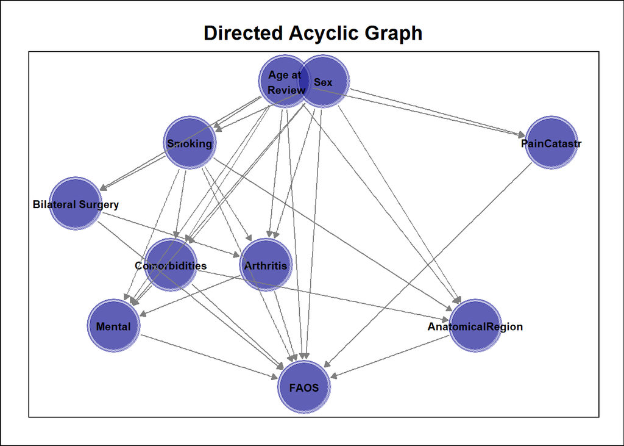

Figure 2: Directed acyclic graph of baseline FAOS against anatomical region in foot and ankle pathology

```r
DAGFAOS1 <- ggdag::dagify(FAOS ~ Region + Arthritis + Age + Sex + ComorbidityScore + Smoking + Bilateral + MentalScore + PainCatastrophise,
          Region ~ Age + Sex + Smoking + ComorbidityScore,
          Arthritis ~ Bilateral + Age + Sex + Smoking,
          Smoking ~ Age + Sex,
          ComorbidityScore ~ Age + Sex + Smoking,
          Bilateral ~ Age + Smoking,
          MentalScore ~ Age + Sex + Smoking + ComorbidityScore + Arthritis,
          PainCatastrophise ~ Age + Sex,
  labels = c(
    "FAOS" = "FAOS",
    "SmokingStatus" = "Smoking History",
    "ComorbidityScore" = "Comorbidities",
    "Age" = "Age at\n Review",
    "Region" = "AnatomicalRegion",
    "Sex" = "Sex",
    "Bilateral" = "Bilateral Presentation",
    "MentalScore" = "Mental",
    "PainCatastrophise" ~ "PainCatastr"
  ),
  exposure = "Region",
  outcome = "FAOS"
)

# Create a tidy version of the DAG and apply custom labels
tidy_dag1 <- ggdag::tidy_dagitty(DAGFAOS1, layout = "auto") |>
  mutate(label = case_when(
    name == "FAOS" ~ "FAOS",
    name == "SmokingStatus" ~ "Smoking History",
    name == "ComorbidityScore" ~ "Comorbidities",
    name == "Age" ~ "Age at\n Review",
    name == "Region" ~ "AnatomicalRegion",
    name == "MentalScore" ~ "Mental",
    name == "Bilateral" ~ "Bilateral Surgery",
    name == "PainCatastrophise" ~ "PainCatastr",
    name == "Sex" ~ "Sex",
    TRUE ~ name
  ))

dagraw <- ggplot(
  tidy_dag1,
  aes(
    x = x,
    y = y,
    xend = xend,
    yend = yend)
  ) +
  geom_dag_node(
    color = "darkblue",
    fill = "lightblue",
    alpha = 0.5,
    size = 20) +
  geom_dag_text(
    aes(
      label = label
      ),
    color = "black",
    fontface = "bold",
    size = 3,
    vjust = 0.5
    ) +
  geom_dag_edges(
    edge_color = "gray50",
    edge_width = 0.5,
    #edge_arrow_size = 0.3
    ) +
  theme_dag(
    base_size = 12,
    base_family = "",
    plot.background = element_rect(fill = "white"),
    panel.background = element_rect(fill = "white")
  ) +
  theme(
    plot.title = element_text(
      hjust = 0.5,
      size = 16,
      face = "bold"
      ),
    plot.margin = margin(
      20,
      20,
      20,
      20
      )
  ) +
  ggtitle(
    "Directed Acyclic Graph"
    )

knitr::knit_print(dagraw)
```

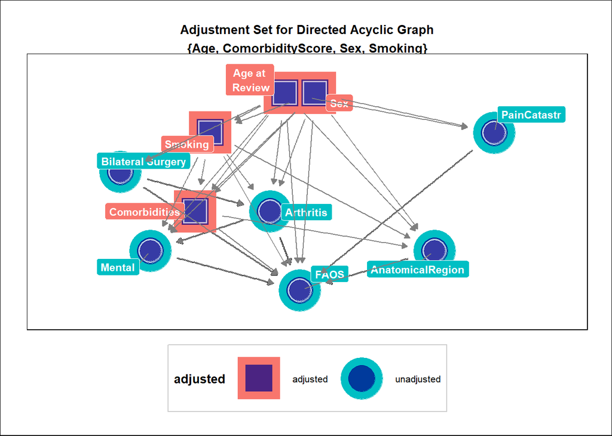

Figure 3: Calculated minimum adjustment set for modelling FAOS against anatomical region in foot-ankle pathology

```r
dagmin <- ggdag_adjustment_set(
  tidy_dag1,
  text = FALSE,
  #use_labels = "label"
  exposure = "Region",
  outcome = "FAOS"
  ) +
  geom_dag_node(
    color = "darkblue",
    fill = "lightblue",
    alpha = 0.7,
    size = 10
  ) +
  # geom_dag_text(
  #   aes(label = label),  # Use the 'label' column directly
  #   color = "black",
  #   fontface = "bold",
  #   size = 3,
  #   vjust = -1.5,  # Adjust vertical position
  #   hjust = 1.5,  # Adjust horizontal position
  #   show.legend = FALSE  # Prevent text from appearing in legend
  # ) +
  geom_dag_label_repel(
    aes(label = label, fill = adjusted),
    color = "white",
    fontface = "bold",
    size = 3,
    show.legend = FALSE,
    box.padding = unit(0.5, "lines"),  # Padding around labels
    point.padding = unit(0.5, "lines"),  # Padding around points
    nudge_y = 0.5,  # Adjust vertical nudge
    nudge_x = 0.5   # Adjust horizontal nudge
  ) +
  geom_dag_edges(
    edge_color = "gray50",
    edge_width = 0.5
  ) +
  theme_dag(
    base_size = 10,
    base_family = "",
    plot.background = element_rect(fill = "white"),
    panel.background = element_rect(fill = "white")
  ) +
  theme(
    plot.title = element_text(
      hjust = 0.5,
      size = 10,
      face = "bold"
    ),
    plot.margin = margin(20,20,20,20),
    legend.position = "bottom",
    legend.background = element_rect(fill = "white", color = "gray80"),
    legend.title = element_text(face = "bold")
  ) +
  ggtitle("Adjustment Set for Directed Acyclic Graph")


knitr::knit_print(dagmin)
```

### 3.9.3 RECORD [12.1] Data access

The registry system represents all cases presenting to the rooms of collaborating specialists within Sydney, Australia from the inception of the clinical registry to the analysis date. All reviewed charts from the operating surgeons practice records (electronic medical record) were entered into database and the present analysis draws data from a regular compilation of the registry records (snapshot) produced quarterly by the registry administration team.

### 3.9.4 RECORD [12.2] Data Cleaning

Text data was cleaned using custom functions as described in *Functions for processing*.

#### 3.9.4.1 Missingness

In the record selection workflow, patients with text in the diagnosis text field were included in the final analysis number. However, there was a proportion of patients that had text that could not be categorised into an anatomical region. For the purposes of this draft analysis, these cases will be removed and a round of chart review will be performed to resolve the discrepancy between the text and the classification code.

```r
MasterAnalysis <- MasterTable6 |> dplyr::select(
  TreatmentID,
  PatientID,
  TreatmentType,
  Sex2,
  Provider,
  BilateralStatus,
  AgeAtInitialExam,
  SmokingStatus_Preop,
  InjuryToPresentation,
  VR12_Physical_TotalScore_Preop,
  VR12_Mental_TotalScore_Preop,
  SRCQTotalScore,
  PCSSF_TotalScore_Preop,
  PreviousPath,
  PreviousSurgery,
  SurgicalTreatment,
  Term3,
  Region,
  starts_with("FAOS")
) |> mutate( #Fix up pathology, add bilateralpath
  SmokingStatus = forcats::fct(
    SmokingStatus_Preop,
    levels = c(
      "Never smoked",
      "Non smoker for >12 months",
      "Non smoker for <12 months",
      "Yes - current smoker"
    )
  ),
  Arthritis = if_else(
    stringr::str_detect(Term3,"arthrit"),
    "Yes",
    "No"
  )
) |> dplyr::select(
 -c(
   Term3,
   SmokingStatus_Preop
 )
)
```

Missingness was visualised with the *naniar* package (v1.1.0) (Tierney and Cook 2023). It showed that patients with a diagnosis also had other missing data, predominantly PROMs data.

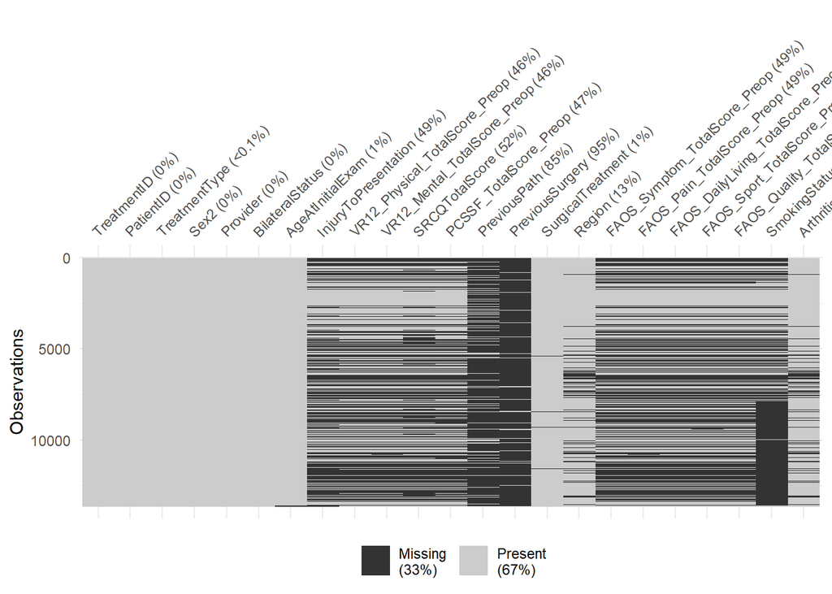

Figure 4: Patterns of missingness across analysis variables

```r
vis_miss(MasterAnalysis)
```

```r
# Drop variables due to excessive missingness
#
#

MasterAnalysis1 <- MasterAnalysis |>
  mutate(
    SubsetGroup_temp = case_when(
Region == "Ankle" & Arthritis == "Yes" ~ "AnkleArthritis",
Region == "Multiple" & Arthritis == "Yes" ~ "MultipleArthritis",
Region == "Ankle" & Arthritis == "No" ~ "AnkleNonArthritis",
.default = NA_character_
),  # Use forcats to create factors with strict level control
  SubsetGroup = fct_relevel(factor(SubsetGroup_temp), "AnkleArthritis", "AnkleNonArthritis","MultipleArthritis"),
  SmokingStatus = if_else(is.na(SmokingStatus), NA_character_, SmokingStatus),
  SmokingStatus = forcats::fct(
    SmokingStatus,
    levels = c("Never smoked","Non smoker for >12 months","Non smoker for <12 months","Yes - current smoker")
           ),
  Sex2 = forcats::fct(
    Sex2,
    levels = c("Male","Female")
    ),
  Region = forcats::fct(
    Region,
    levels = c("Ankle","Foot","Multiple","Hindfoot","Midfoot","Forefoot")
    ),
  Provider = forcats::fct(
    Provider,
    levels = c("AW","MS2","MS1","RM")
    ),
  SurgicalTreatment = forcats::fct(
    SurgicalTreatment,
    levels = c("Non-Surgical","Surgical")
    ),
  Arthritis = forcats::fct(
    Arthritis,
    levels = c("No","Yes")
  ),
  BilateralStatus = forcats::fct(
    BilateralStatus,
    levels = c("Bilateral","Unilateral")
  )
) |> dplyr::select(
  -(c(
  TreatmentID,
  PreviousPath,
  PreviousSurgery,
  TreatmentType,
  SubsetGroup_temp
  )
  )
)
```

The *mice* package was used to impute the dataset. A predictor matrix was created to remove record identifiers and passive variables (e.g. PCS categorisation) from the imputation. Imputation was performed over 20 replications and stored in a variable for further processing.

#### 3.9.4.2 Management

```r
# Check unique values for each categorical variable
categorical_vars <- c("Sex2", "Provider", "BilateralStatus", "SurgicalTreatment",
                     "Region", "SmokingStatus", "Arthritis")

MasterAnalysis1 |>
  select(all_of(categorical_vars)) |>
  map_dfr(~ tibble(
    unique_values = length(unique(.x)),
    unique_non_missing = length(unique(.x[!is.na(.x)])),
    missing_count = sum(is.na(.x)),
    total_count = length(.x)
  ), .id = "variable") |>
  mutate(
    has_variation = unique_non_missing > 1,
    problem = case_when(
      unique_non_missing <= 1 ~ "No variation in non-missing values",
      missing_count == total_count ~ "All values missing",
      TRUE ~ "OK"
    )
  )
```

```
# A tibble: 7 × 7
  variable          unique_values unique_non_missing missing_count total_count
  <chr>                     <int>              <int>         <int>       <int>
1 Sex2                          3                  2            35       13652
2 Provider                      4                  4             0       13652
3 BilateralStatus               2                  2             0       13652
4 SurgicalTreatment             3                  2            76       13652
5 Region                        7                  6          1826       13652
6 SmokingStatus                 5                  4          8788       13652
7 Arthritis                     3                  2          1826       13652
# ℹ 2 more variables: has_variation <lgl>, problem <chr>
```

```r
# Also check the actual values
epoxy("Checking actual values for problematic variables:")
```

```
Checking actual values for problematic variables:
```

```r
for(var in categorical_vars) {
  cat("\n", var, ":\n")
  print(table(MasterAnalysis1[[var]], useNA = "always"))
}
```

```
 Sex2 :

  Male Female   <NA>
  5997   7620     35

 Provider :

  AW  MS2  MS1   RM <NA>
8583 2669 1172 1228    0

 BilateralStatus :

 Bilateral Unilateral       <NA>
      1998      11654          0

 SurgicalTreatment :

Non-Surgical     Surgical         <NA>
        9577         3999           76

 Region :

   Ankle     Foot Multiple Hindfoot  Midfoot Forefoot     <NA>
    4012      122     2981      638     1139     2934     1826

 SmokingStatus :

             Never smoked Non smoker for >12 months Non smoker for <12 months
                     3299                      1073                       244
     Yes - current smoker                      <NA>
                      248                      8788

 Arthritis :

  No  Yes <NA>
8601 3225 1826
```

```r
predM <- mice::make.predictorMatrix(MasterAnalysis1)

# Exclude ID and non-predictive variables
predM[,"PatientID"] <- 0
predM["PatientID",] <- 0
predM[,"SubsetGroup"] <- 0
predM["SubsetGroup",] <- 0

# Create method vector
meth <- mice::make.method(MasterAnalysis1)

# Create visit sequence
visitSeq <- mice::make.visitSequence(MasterAnalysis1)

visitSeq <- c(
  "PatientID",
  "Provider",
  "SurgicalTreatment",
  "BilateralStatus",
  "AgeAtInitialExam",
  "Sex2",
  "VR12_Physical_TotalScore_Preop",
  "SRCQTotalScore",
  "VR12_Mental_TotalScore_Preop",
  "InjuryToPresentation",
  "SmokingStatus",
  "Arthritis",
  "Region",
  "PCSSF_TotalScore_Preop",
  "FAOS_Pain_TotalScore_Preop",
  "FAOS_Symptom_TotalScore_Preop",
  "FAOS_DailyLiving_TotalScore_Preop",
  "FAOS_Sport_TotalScore_Preop",
  "FAOS_Quality_TotalScore_Preop"
)

# Set methods - only for variables that need imputation
meth["PatientID"] <- ""           # Don't impute ID
meth["AgeAtInitialExam"] <- ""    # Don't impute age
meth["Provider"] <- ""            # No missing values, don't impute
meth["BilateralStatus"] <- ""     # No missing values, don't impute

# Passive imputation for derived variables - use fct_relevel to ensure consistent levels
meth["SubsetGroup"] <- "~I(forcats::fct_relevel(factor(case_when(
Region == `Ankle` & Arthritis == `Yes` ~ `AnkleArthritis`,
Region == `Multiple` & Arthritis == `Yes` ~`MultipleArthritis`,
Region == `Ankle` & Arthritis == `No` ~ `AnkleNonArthritis`
)), 'AnkleArthritis', 'AnkleNonArthritis',`MultipleArthritis`))"
```

```r
 MasterImp <- mice::mice(
    MasterAnalysis1,
    maxit = 10,  # Start with just 1 iteration to test
    seed = 4218,
    m = 20,      # Fewer imputations for testing
    printFlag = FALSE,
    predictorMatrix = predM,
    visitSequence = visitSeq,
    method = meth
  )
```

A strip plot was used to visually inspect the convergence of the imputation iterations against the original dataset.

```r
MasterImpStrip <- mice::densityplot(MasterImp)

knitr::knit_print(MasterImpStrip)
```

[output not shown]

The estimated FAOS-Pain subscore from the imputation model versus the distribution of the observed data was plotted as a visual inspection of the imputation result.

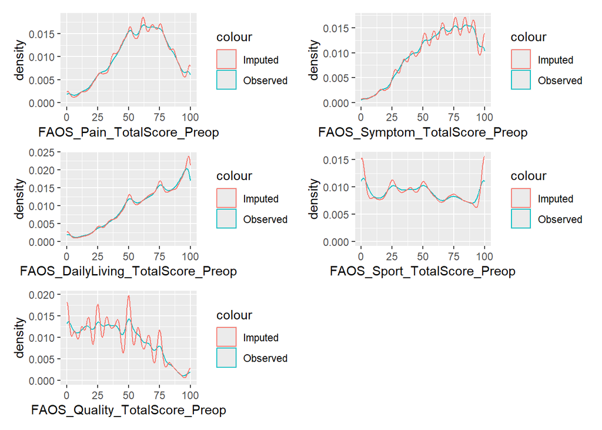

Figure 5: Estimated versus observed FAOS subcales for the analysis cohort.

```r
FAOSPainImp <- ggplot() +
  geom_density(data = complete(MasterImp, 1), aes(x = FAOS_Pain_TotalScore_Preop, color = "Observed")) +
  geom_density(data = complete(MasterImp, 2:10), aes(x = FAOS_Pain_TotalScore_Preop, color = "Imputed"))

FAOSSympImp <- ggplot() +
  geom_density(data = complete(MasterImp, 1), aes(x = FAOS_Symptom_TotalScore_Preop, color = "Observed")) +
  geom_density(data = complete(MasterImp, 2:10), aes(x = FAOS_Symptom_TotalScore_Preop, color = "Imputed"))

FAOSDailyImp <- ggplot() +
  geom_density(data = complete(MasterImp, 1), aes(x = FAOS_DailyLiving_TotalScore_Preop, color = "Observed")) +
  geom_density(data = complete(MasterImp, 2:10), aes(x = FAOS_DailyLiving_TotalScore_Preop, color = "Imputed"))

FAOSSportImp <- ggplot() +
  geom_density(data = complete(MasterImp, 1), aes(x = FAOS_Sport_TotalScore_Preop, color = "Observed")) +
  geom_density(data = complete(MasterImp, 2:10), aes(x = FAOS_Sport_TotalScore_Preop, color = "Imputed"))

FAOSQualityImp <- ggplot() +
  geom_density(data = complete(MasterImp, 1), aes(x = FAOS_Quality_TotalScore_Preop, color = "Observed")) +
  geom_density(data = complete(MasterImp, 2:10), aes(x = FAOS_Quality_TotalScore_Preop, color = "Imputed"))

(FAOSPainImp + FAOSSympImp + FAOSDailyImp + FAOSSportImp + FAOSQualityImp) + patchwork::plot_layout(ncol = 2)
```

### 3.9.5 RECORD [12.3] Linkage

No data linkage was performed for this analysis.

### 3.9.6 Analysis Methods

Participant flow - consort package and flow chart Descriptive - gtsummary and prepared for display with knitr Outcome data - ggplot2 complete case analysis

**Functions to fit fixest models with clustered standard errors for unadjusted and adjusted Region models**

```r
# Define FAOS subscales
faos_subscales <- c("FAOS_Pain_TotalScore_Preop",
                    "FAOS_DailyLiving_TotalScore_Preop",
                    "FAOS_Symptom_TotalScore_Preop",
                    "FAOS_Sport_TotalScore_Preop",
                    "FAOS_Quality_TotalScore_Preop")

subscale_labels <- c("Pain", "Daily Living", "Symptoms", "Sport", "Quality of Life")

# Function to run models for each subscale
run_subscale_models <- function(outcome_var, formula_str, model_label) {

  # Create models for this subscale
  models <- map(1:MasterImp$m, ~ {
    fixest::feols(
      as.formula(paste(outcome_var, formula_str)),
      data = complete(MasterImp, action = .x),
      cluster = ~PatientID
    )
  })

  # Pool parameters and add labels
  parameters::pool_parameters(models) |>
    mutate(
      Model = model_label,
      Subscale = subscale_labels[which(faos_subscales == outcome_var)]
    )
}

# Create unadjusted models for all subscales
unadjusted_results <- map_dfr(faos_subscales, ~ {
  run_subscale_models(.x, "~ Region", paste("Unadjusted -", subscale_labels[which(faos_subscales == .x)]))
})

# Create adjusted models for all subscales
adjusted_results <- map_dfr(faos_subscales, ~ {
  run_subscale_models(.x, "~ Region + AgeAtInitialExam + Sex2 + SRCQTotalScore",
                     paste("Adjusted -", subscale_labels[which(faos_subscales == .x)]))
})
```

The models were summarised using *parameters* and *gt* packages. Predicted values for all model variables were generated from the model object using *marginaleffects*.

# 4 Results

## 4.1 RECORD [13] Participants

The initial export from the registry returned 21636 treatment records of all types.

### 4.1.1 RECORD [13.1] Participant Flow

The diagram below summarises recruitment and categorisation of patients from the SOFARI registry into the final analysis cohort.

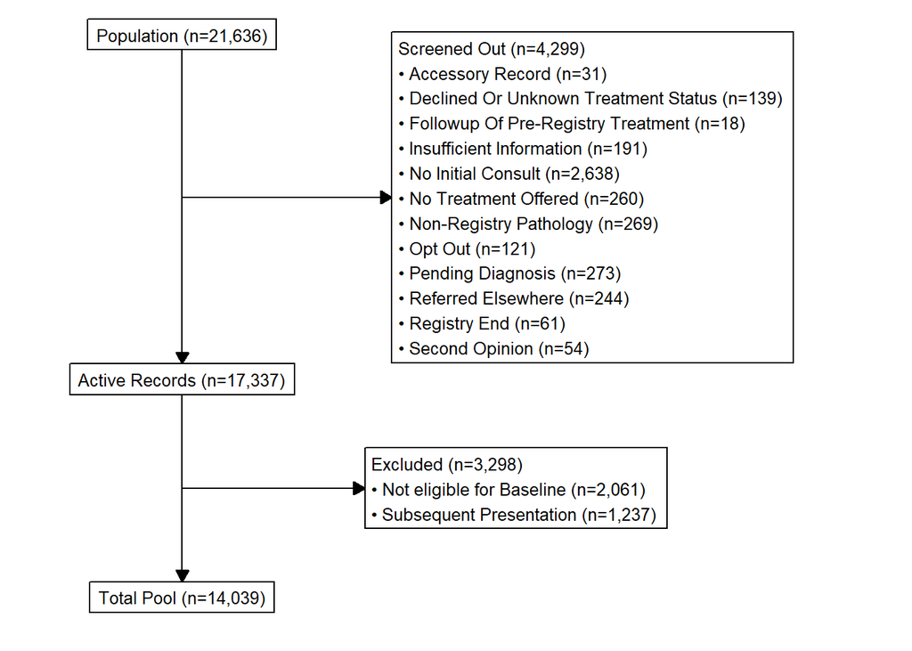

Figure 6: Flow chart of treatment record inclusion for analysis.

```r
STROBEplot <- consort_plot(
  data = STROBEFlow,
  orders = c(
    trialno = "Population",
    exclusion1 = "Screened Out",
    trialno = "Active Records",
    exclusion2 = "Excluded",
    trialno = "Total Pool"
    #exclusion3 = "Not Available",
    #trialno = "Available Pool"
  ),
  side_box = c(
    "exclusion1",
    "exclusion2"
    #"exclusion3"
  ),
  cex = 0.8
)

knitr::knit_print(STROBEplot)
```

## 4.2 RECORD [14] Patient Characteristics

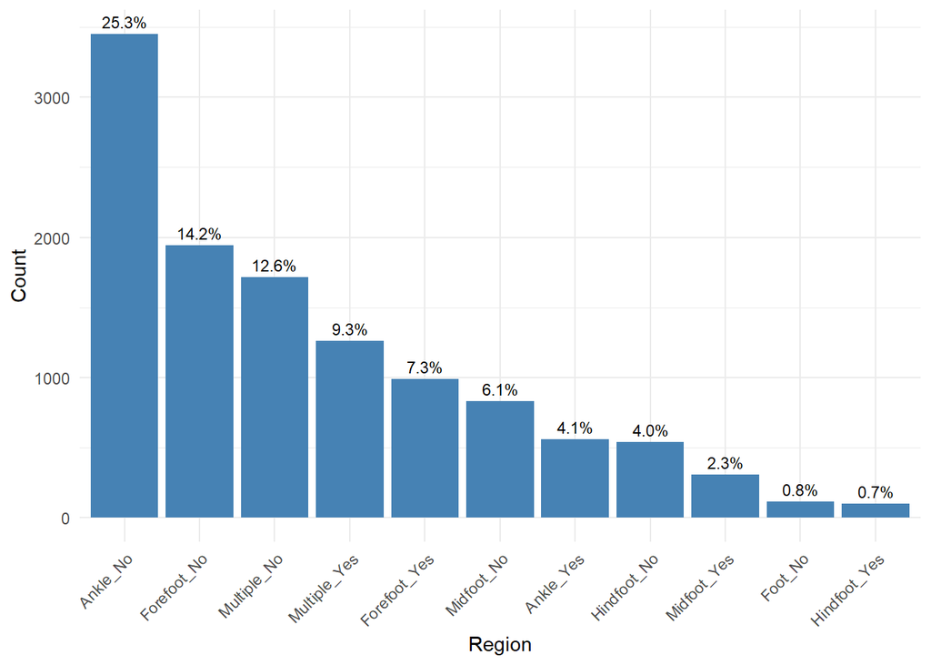

Figure 7: Breakdown of sample by diagnostic group (region) labels and presence of arthritis.

```r
min_count <- 10

# Basic counts
  basic_counts2 <- MasterAnalysis1 |>
    count(Region,Arthritis, sort = TRUE) |>
    mutate(
      percentage = n / sum(n) * 100,
      cumulative_percentage = cumsum(percentage)
    ) |> tidyr::unite(
      "RegionArthritis",
      Region:Arthritis,
      remove = FALSE
    )


 # Create visualization
  plot_data <- basic_counts2 |>
    filter(
      n >= min_count,
      !is.na(Region)
      )  # Filter for readability

  cohort_plot <- ggplot(plot_data, aes(x = reorder(RegionArthritis, -n), y = n)) +
    geom_bar(stat = "identity", fill = "steelblue") +
    geom_text(aes(label = sprintf("%.1f%%", percentage)),
              vjust = -0.5, size = 3) +
    theme_minimal() +
    theme(axis.text.x = element_text(angle = 45, hjust = 1)) +
    labs(
         x = "Region",
         y = "Count")

  knitr::knit_print(cohort_plot)
```

Patient characteristics for the sample are summarised.

```r
TblDemo <- gtsummary::tbl_summary(
  MasterTable6,
  include = c(
    AgeAtInitialExam,
    Sex2,
    Provider2,
    BilateralStatus,
    VR12_Physical_TotalScore_Preop,
    VR12_Mental_TotalScore_Preop,
    SRCQTotalScore,
    InjuryToPresentation,
    PCSSF_TotalScore_Preop,
    Region
  ),
by = "Region",
label = list(
    Provider2 ~ "Provider",
    AgeAtInitialExam ~ "Age",
    InjuryToPresentation ~ "Onset to Presentation (Days)",
    BilateralStatus ~ "Bilateral",
    #Region ~ "Anatomical Region",
    Sex2 ~ "Female",
    VR12_Physical_TotalScore_Preop ~ "Physical Score",
    VR12_Mental_TotalScore_Preop ~ "Mental Score",
    SRCQTotalScore ~ "Comorbidity Score",
    PCSSF_TotalScore_Preop ~ "Pain Catastrophising"
    ),
    type = list(
    Sex2 ~ "dichotomous",
    BilateralStatus ~ "dichotomous"
    ),
    value = list(
      Sex2 ~ "Female",
      BilateralStatus ~ "Bilateral"
    ),
    statistic = list(
      all_continuous() ~ "{mean} ({sd})",
      all_categorical() ~ "{p}% ({n})"
      ),
    missing = "no"
)

# |> gtsummary::add_n() |>
#   gtsummary::add_overall() |>
#   gtsummary::add_ci(statistic = list(all_categorical() ~ "{conf.low} - {conf.high}",
#                           all_continuous() ~ "{conf.low} - {conf.high}"),
#                           conf.level = 0.99,
#                           ) |>
#   gtsummary::add_stat_label(
#     location = "row"
#   )


knitr::knit_print(TblDemo)
```

Table 7: Summary of patient and treatment record characteristics for the analysed sample.

| **Characteristic** | **Ankle** N = 4,012<sup>1</sup> | **Foot** N = 122<sup>1</sup> | **Forefoot** N = 2,934<sup>1</sup> | **Hindfoot** N = 638<sup>1</sup> | **Midfoot** N = 1,139<sup>1</sup> | **Multiple** N = 2,981<sup>1</sup> |
| --- | --- | --- | --- | --- | --- | --- |
| Age | 45 (18) | 47 (19) | 55 (17) | 49 (15) | 48 (19) | 52 (18) |
| Female | 45% (1,795) | 47% (57) | 69% (2,014) | 55% (351) | 61% (690) | 57% (1,696) |
| Provider |  |  |  |  |  |  |
| A | 60% (2,425) | 50% (61) | 71% (2,077) | 53% (336) | 52% (595) | 67% (2,007) |
| B | 25% (984) | 17% (21) | 17% (500) | 28% (179) | 27% (309) | 18% (548) |
| C | 6.7% (268) | 23% (28) | 6.2% (181) | 7.2% (46) | 9.6% (109) | 8.5% (254) |
| D | 8.3% (335) | 9.8% (12) | 6.0% (176) | 12% (77) | 11% (126) | 5.8% (172) |
| Bilateral | 5.2% (207) | 25% (30) | 29% (865) | 16% (104) | 8.6% (98) | 14% (413) |
| Physical Score | 36 (11) | 35 (12) | 43 (10) | 37 (11) | 36 (11) | 37 (11) |
| Mental Score | 51 (11) | 47 (13) | 53 (10) | 50 (12) | 51 (11) | 51 (11) |
| Comorbidity Score | 2.38 (2.83) | 3.83 (3.13) | 2.79 (3.06) | 2.46 (2.79) | 2.51 (2.90) | 2.84 (2.95) |
| Onset to Presentation (Days) | 185 (431) | 655 (932) | 410 (563) | 185 (395) | 165 (409) | 319 (568) |
| Pain Catastrophising | 8 (6) | 10 (7) | 8 (6) | 10 (7) | 8 (6) | 9 (6) |

<sup>1</sup> Mean (SD); % (n)

## 4.3 RECORD [15] Outcome data

```r
#Summarise outcome data
#
#

TableFAOS <- gtsummary::tbl_summary(
  MasterAnalysis1,
  include = c(contains("FAOS")),
 missing = "no",
 statistic = list(everything() ~ "{mean} ({sd})")
)

knitr::knit_print(TableFAOS)
```

| **Characteristic** | **N = 13,652**<sup>1</sup> |
| --- | --- |
| FAOS_Symptom_TotalScore_Preop | 65 (23) |
| FAOS_Pain_TotalScore_Preop | 61 (22) |
| FAOS_DailyLiving_TotalScore_Preop | 70 (24) |
| FAOS_Sport_TotalScore_Preop | 49 (32) |
| FAOS_Quality_TotalScore_Preop | 38 (25) |

<sup>1</sup> Mean (SD)

Correlation matrix for FAOS subscales

[output not shown]

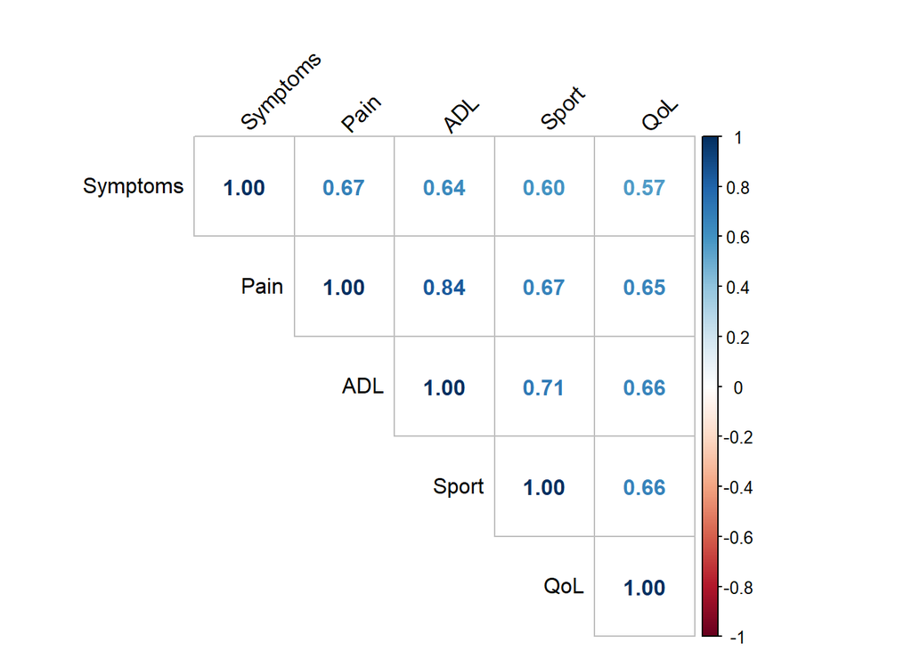

Figure 8: Correlation matrix for FAOS subscales at baseline using imputed data

```r
# Function to calculate correlations for each imputed dataset
calc_faos_corr <- function(imp_data) {
  faos_data <- imp_data |>
    dplyr::select(contains("FAOS")) |>
    dplyr::rename(
      Pain = "FAOS_Pain_TotalScore_Preop",
      ADL = "FAOS_DailyLiving_TotalScore_Preop",
      Symptoms = "FAOS_Symptom_TotalScore_Preop",
      Sport = "FAOS_Sport_TotalScore_Preop",
      QoL = "FAOS_Quality_TotalScore_Preop"
    )

  return(cor(faos_data, use = "complete.obs"))
}

# Calculate correlations for each imputed dataset
if (class(MasterImp) == "mids") {
  # If MasterImp is a mids object (from mice)
  corr_list <- map(1:MasterImp$m, function(i) {
    imp_data <- complete(MasterImp, i)
    calc_faos_corr(imp_data)
  })

  # Pool the correlation matrices (average across imputations)
  FAOSCorr <- Reduce("+", corr_list) / length(corr_list)

  # Alternative: Use Rubin's rules for pooling (more complex but more accurate)
  # This would require additional functions for pooling correlations

} else {
  # If MasterImp is already a completed imputed dataset
  FAOSCorr <- calc_faos_corr(MasterImp)
}

# Create the correlation plot
FAOSCorrPlot <- corrplot(
  FAOSCorr,
  method = "number",
  type = "upper",
  #title = "FAOS Subscales Correlation (Imputed Data)",
  mar = c(0,0,2,0),
  tl.col = "black",
  tl.srt = 45
)

knitr::knit_print(FAOSCorrPlot)
```

## 4.4 RECORD [16] Main results

```r
# Create unadjusted stacked table
unadjusted_table <- unadjusted_results |>
  gt(groupname_col = "Model") |>
  fmt_number(
    columns = c(Statistic),
    decimals = 1
  ) |>
  fmt_number(
    columns = c(Coefficient, SE, CI_low, CI_high, df_error),
    decimals = 2
  ) |>
  fmt_number(
    columns = c(p),
    decimals = 3
  ) |>
  cols_label(
    Parameter = "Parameter",
    Coefficient = "Coefficient",
    SE = "Standard Error",
    CI_low = "95% CI Lower",
    CI_high = "95% CI Upper",
    Statistic = "t-statistic",
    df_error = "df",
    p = "p-value"
  ) |>
  tab_style(
    style = cell_text(weight = "bold"),
    locations = cells_row_groups()
  ) |>
  cols_hide(columns = "Subscale")


knitr::knit_print(unadjusted_table)
```

Table 8: Summary of regression assessing the effect of region on FAOS subscales unadjusted for covariates

| Parameter | Coefficient | Standard Error | 95% CI Lower | 95% CI Upper | t-statistic | df | p-value |
| --- | --- | --- | --- | --- | --- | --- | --- |
| Unadjusted - Pain |  |  |  |  |  |  |  |
| (Intercept) | 55.90 | 0.44 | 55.02 | 56.78 | 126.6 | 89.35 | 0.000 |
| RegionFoot | 5.44 | 2.86 | −0.25 | 11.13 | 1.9 | 84.06 | 0.061 |
| RegionMultiple | 2.19 | 0.67 | 0.85 | 3.53 | 3.2 | 90.45 | 0.002 |
| RegionHindfoot | 0.76 | 1.32 | −1.88 | 3.41 | 0.6 | 63.90 | 0.567 |
| RegionMidfoot | 1.62 | 0.85 | −0.05 | 3.29 | 1.9 | 188.91 | 0.057 |
| RegionForefoot | 13.74 | 0.71 | 12.32 | 15.15 | 19.4 | 65.30 | 0.000 |
| Unadjusted - Daily Living |  |  |  |  |  |  |  |
| (Intercept) | 63.87 | 0.50 | 62.88 | 64.87 | 127.6 | 78.24 | 0.000 |
| RegionFoot | 1.45 | 3.33 | −5.21 | 8.12 | 0.4 | 59.63 | 0.664 |
| RegionMultiple | 4.23 | 0.73 | 2.78 | 5.68 | 5.8 | 93.21 | 0.000 |
| RegionHindfoot | 2.33 | 1.45 | −0.57 | 5.23 | 1.6 | 59.52 | 0.114 |
| RegionMidfoot | 1.61 | 0.94 | −0.25 | 3.46 | 1.7 | 178.15 | 0.089 |
| RegionForefoot | 15.18 | 0.76 | 13.66 | 16.71 | 19.9 | 63.29 | 0.000 |
| Unadjusted - Symptoms |  |  |  |  |  |  |  |
| (Intercept) | 56.19 | 0.43 | 55.33 | 57.05 | 130.1 | 104.40 | 0.000 |
| RegionFoot | −0.11 | 2.69 | −5.44 | 5.22 | 0.0 | 127.66 | 0.966 |
| RegionMultiple | 8.21 | 0.64 | 6.94 | 9.48 | 12.8 | 128.30 | 0.000 |
| RegionHindfoot | 10.96 | 1.16 | 8.66 | 13.27 | 9.4 | 111.19 | 0.000 |
| RegionMidfoot | 10.25 | 0.83 | 8.62 | 11.89 | 12.4 | 168.00 | 0.000 |
| RegionForefoot | 21.74 | 0.64 | 20.47 | 23.00 | 34.1 | 85.54 | 0.000 |
| Unadjusted - Sport |  |  |  |  |  |  |  |
| (Intercept) | 38.86 | 0.65 | 37.56 | 40.15 | 59.9 | 69.41 | 0.000 |
| RegionFoot | 6.44 | 3.93 | −1.38 | 14.27 | 1.6 | 80.79 | 0.105 |
| RegionMultiple | 7.60 | 0.94 | 5.74 | 9.46 | 8.1 | 96.42 | 0.000 |
| RegionHindfoot | 8.58 | 1.89 | 4.80 | 12.35 | 4.5 | 60.16 | 0.000 |
| RegionMidfoot | 7.22 | 1.32 | 4.60 | 9.84 | 5.5 | 100.62 | 0.000 |
| RegionForefoot | 26.88 | 1.03 | 24.81 | 28.94 | 26.0 | 59.47 | 0.000 |
| Unadjusted - Quality of Life |  |  |  |  |  |  |  |
| (Intercept) | 30.85 | 0.50 | 29.85 | 31.84 | 62.0 | 70.61 | 0.000 |
| RegionFoot | 1.90 | 2.87 | −3.75 | 7.56 | 0.7 | 209.31 | 0.508 |
| RegionMultiple | 5.07 | 0.73 | 3.62 | 6.52 | 6.9 | 92.92 | 0.000 |
| RegionHindfoot | 3.57 | 1.27 | 1.05 | 6.09 | 2.8 | 113.07 | 0.006 |
| RegionMidfoot | 5.04 | 1.12 | 2.81 | 7.28 | 4.5 | 69.67 | 0.000 |
| RegionForefoot | 19.33 | 0.89 | 17.54 | 21.13 | 21.7 | 50.93 | 0.000 |

```r
# Create adjusted stacked table
adjusted_table <- adjusted_results |>
  gt(groupname_col = "Model") |>
  tab_header(
    title = "Adjusted Regression Results",
    subtitle = "FAOS Subscales ~ Region + Age + Sex + SRCQ Total Score"
  ) |>
  fmt_number(
    columns = c(Statistic),
    decimals = 1
  ) |>
  fmt_number(
    columns = c(Coefficient, SE, CI_low, CI_high, df_error),
    decimals = 2
  ) |>
  fmt_number(
    columns = c(p),
    decimals = 3
  ) |>
  cols_label(
    Parameter = "Parameter",
    Coefficient = "Coefficient",
    SE = "Standard Error",
    CI_low = "95% CI Lower",
    CI_high = "95% CI Upper",
    Statistic = "t-statistic",
    df_error = "df",
    p = "p-value"
  ) |>
  tab_style(
    style = cell_text(weight = "bold"),
    locations = cells_row_groups()
  ) |>
  cols_hide(columns = "Subscale")


knitr::knit_print(adjusted_table)
```

Table 9: Summary of regression assessing the effect of region on FAOS adjusted for confounders

Adjusted Regression Results

FAOS Subscales ~ Region + Age + Sex + SRCQ Total Score

| Parameter | Coefficient | Standard Error | 95% CI Lower | 95% CI Upper | t-statistic | df | p-value |
| --- | --- | --- | --- | --- | --- | --- | --- |
| Adjusted - Pain |  |  |  |  |  |  |  |
| (Intercept) | 57.79 | 0.78 | 56.25 | 59.34 | 74.5 | 97.03 | 0.000 |
| RegionFoot | 6.75 | 2.84 | 1.10 | 12.41 | 2.4 | 80.10 | 0.020 |
| RegionMultiple | 2.75 | 0.68 | 1.39 | 4.11 | 4.0 | 87.49 | 0.000 |
| RegionHindfoot | 1.14 | 1.32 | −1.49 | 3.78 | 0.9 | 62.91 | 0.390 |
| RegionMidfoot | 2.29 | 0.84 | 0.63 | 3.95 | 2.7 | 188.77 | 0.007 |
| RegionForefoot | 14.59 | 0.73 | 13.12 | 16.06 | 19.9 | 63.59 | 0.000 |
| AgeAtInitialExam | 0.04 | 0.01 | 0.01 | 0.07 | 2.5 | 92.02 | 0.014 |
| Sex2Female | −3.07 | 0.48 | −4.02 | −2.13 | −6.4 | 148.66 | 0.000 |
| SRCQTotalScore | −0.90 | 0.11 | −1.11 | −0.69 | −8.6 | 59.83 | 0.000 |
| Adjusted - Daily Living |  |  |  |  |  |  |  |
| (Intercept) | 66.10 | 0.80 | 64.53 | 67.68 | 82.9 | 143.64 | 0.000 |
| RegionFoot | 2.91 | 3.32 | −3.74 | 9.57 | 0.9 | 57.44 | 0.385 |
| RegionMultiple | 4.74 | 0.74 | 3.28 | 6.20 | 6.4 | 93.33 | 0.000 |
| RegionHindfoot | 2.61 | 1.44 | −0.28 | 5.50 | 1.8 | 58.76 | 0.075 |
| RegionMidfoot | 2.04 | 0.94 | 0.19 | 3.90 | 2.2 | 176.89 | 0.031 |
| RegionForefoot | 15.84 | 0.79 | 14.25 | 17.43 | 19.9 | 60.35 | 0.000 |
| AgeAtInitialExam | 0.02 | 0.02 | −0.02 | 0.05 | 1.0 | 94.49 | 0.338 |
| Sex2Female | −1.09 | 0.53 | −2.15 | −0.04 | −2.1 | 125.43 | 0.042 |
| SRCQTotalScore | −1.00 | 0.11 | −1.23 | −0.77 | −8.8 | 59.61 | 0.000 |
| Adjusted - Symptoms |  |  |  |  |  |  |  |
| (Intercept) | 50.76 | 0.80 | 49.16 | 52.36 | 63.2 | 78.17 | 0.000 |
| RegionFoot | 0.68 | 2.71 | −4.69 | 6.05 | 0.3 | 116.63 | 0.802 |
| RegionMultiple | 7.55 | 0.63 | 6.31 | 8.80 | 12.0 | 145.89 | 0.000 |
| RegionHindfoot | 10.49 | 1.14 | 8.24 | 12.74 | 9.2 | 117.31 | 0.000 |
| RegionMidfoot | 10.03 | 0.82 | 8.42 | 11.64 | 12.3 | 182.37 | 0.000 |
| RegionForefoot | 20.64 | 0.67 | 19.31 | 21.97 | 30.8 | 80.13 | 0.000 |
| AgeAtInitialExam | 0.16 | 0.02 | 0.13 | 0.19 | 10.8 | 79.94 | 0.000 |
| Sex2Female | 0.09 | 0.46 | −0.81 | 1.00 | 0.2 | 200.19 | 0.843 |
| SRCQTotalScore | −0.81 | 0.10 | −1.01 | −0.61 | −8.1 | 58.95 | 0.000 |
| Adjusted - Sport |  |  |  |  |  |  |  |
| (Intercept) | 34.57 | 1.20 | 32.18 | 36.96 | 28.9 | 66.55 | 0.000 |
| RegionFoot | 7.68 | 3.97 | −0.22 | 15.58 | 1.9 | 77.73 | 0.057 |
| RegionMultiple | 7.06 | 0.93 | 5.22 | 8.90 | 7.6 | 103.94 | 0.000 |
| RegionHindfoot | 8.11 | 1.87 | 4.36 | 11.85 | 4.3 | 60.61 | 0.000 |
| RegionMidfoot | 6.96 | 1.32 | 4.35 | 9.57 | 5.3 | 102.60 | 0.000 |
| RegionForefoot | 25.84 | 1.03 | 23.78 | 27.90 | 25.1 | 66.39 | 0.000 |
| AgeAtInitialExam | 0.14 | 0.02 | 0.09 | 0.18 | 6.2 | 75.21 | 0.000 |
| Sex2Female | 1.47 | 0.85 | −0.22 | 3.17 | 1.7 | 55.60 | 0.087 |
| SRCQTotalScore | −1.07 | 0.13 | −1.33 | −0.82 | −8.4 | 90.23 | 0.000 |
| Adjusted - Quality of Life |  |  |  |  |  |  |  |
| (Intercept) | 27.57 | 0.89 | 25.80 | 29.33 | 31.0 | 80.63 | 0.000 |
| RegionFoot | 2.99 | 2.87 | −2.67 | 8.65 | 1.0 | 196.95 | 0.299 |
| RegionMultiple | 4.80 | 0.74 | 3.32 | 6.27 | 6.5 | 88.59 | 0.000 |
| RegionHindfoot | 3.36 | 1.26 | 0.85 | 5.86 | 2.7 | 111.38 | 0.009 |
| RegionMidfoot | 5.13 | 1.12 | 2.89 | 7.37 | 4.6 | 68.90 | 0.000 |
| RegionForefoot | 18.79 | 0.95 | 16.88 | 20.71 | 19.7 | 46.59 | 0.000 |
| AgeAtInitialExam | 0.13 | 0.02 | 0.10 | 0.16 | 8.2 | 108.87 | 0.000 |
| Sex2Female | −0.95 | 0.60 | −2.13 | 0.23 | −1.6 | 85.27 | 0.114 |
| SRCQTotalScore | −0.94 | 0.09 | −1.12 | −0.75 | −10.2 | 151.74 | 0.000 |

```r
# Load required libraries
library(tidyverse)
library(gt)

# Function to create pairwise comparisons from regional coefficients
create_pairwise_comparisons <- function(pooled_results) {

  # Extract regional coefficients (assuming reference is the first region alphabetically)
  regional_coefs <- pooled_results |>
    filter(str_detect(Parameter, "^Region")) |>
    mutate(
      Region = str_remove(Parameter, "^Region"),
      # Clean up coefficient names
      Region = str_trim(Region)
    )

  # Get unique regions from the data
  regions <- unique(regional_coefs$Region)
  reference_region <- setdiff(
    # Assuming you know your reference region - adjust as needed
    c("Ankle", "Foot", "Hindfoot", "Midfoot"), # Replace with your actual regions
    regions
  )[1]

  # Create all pairwise combinations
  all_regions <- c(reference_region, regions)
  pairwise_combinations <- combn(all_regions, 2, simplify = FALSE)

  # Function to calculate pairwise difference
  calculate_pairwise_diff <- function(region1, region2, subscale_data) {

    # Get coefficients (reference region has coefficient = 0)
    coef1 <- if(region1 == reference_region) {
      list(Coefficient = 0, SE = 0)
    } else {
      subscale_data |>
        filter(Region == region1) |>
        select(Coefficient, SE) |>
        as.list()
    }

    coef2 <- if(region2 == reference_region) {
      list(Coefficient = 0, SE = 0)
    } else {
      subscale_data |>
        filter(Region == region2) |>
        select(Coefficient, SE) |>
        as.list()
    }

    # Calculate difference and combined SE
    diff_estimate <- coef1$Coefficient - coef2$Coefficient

    # For pooled results, we approximate the SE of the difference
    # This is conservative but reasonable for presentation
    combined_se <- sqrt(coef1$SE^2 + coef2$SE^2)

    # Calculate t-statistic and p-value (using large sample approximation)
    t_stat <- diff_estimate / combined_se
    p_value <- 2 * pnorm(abs(t_stat), lower.tail = FALSE)

    tibble(
      comparison = paste(region1, "vs", region2),
      estimate = diff_estimate,
      std.error = combined_se,
      statistic = t_stat,
      p.value = p_value
    )
  }

  # Create pairwise comparisons for each subscale and model type
  results <- pooled_results |>
    filter(str_detect(Parameter, "^Region")) |>
    mutate(Region = str_remove(Parameter, "^Region")) |>
    select(Subscale, Model, Region, Coefficient, SE) |>
    nest(data = c(Region, Coefficient, SE)) |>
    mutate(
      pairwise_comparisons = map(data, ~ {
        subscale_data <- .x
        map_dfr(pairwise_combinations, ~ {
          calculate_pairwise_diff(.x[1], .x[2], subscale_data)
        })
      })
    ) |>
    select(-data) |>
    unnest(pairwise_comparisons)

  return(results)
}

# Create pairwise comparisons
all_pairwise_results <- bind_rows(
  create_pairwise_comparisons(unadjusted_results),
  create_pairwise_comparisons(adjusted_results)
)

# Extract model type from Model column
all_pairwise_results <- all_pairwise_results |>
  mutate(
    model_type = case_when(
      str_detect(Model, "Unadjusted") ~ "Unadjusted",
      str_detect(Model, "Adjusted") ~ "Adjusted",
      TRUE ~ "Unknown"
    )
  )

# Apply FDR correction within each subscale and model type
final_results <- all_pairwise_results |>
  group_by(Subscale, model_type) |>
  mutate(
    p_fdr = p.adjust(p.value, method = "fdr"),
    significance = case_when(
      p_fdr < 0.001 ~ "***",
      p_fdr < 0.01 ~ "**",
      p_fdr < 0.05 ~ "*",
      TRUE ~ ""
    )
  ) |>
  ungroup()

# Filter for significant or near-significant results and prepare for stacked table
stacked_data <- final_results |>
  filter(p.value < 0.06) |>  # Filter for p < 0.06
  select(Subscale, comparison, model_type, estimate, std.error, p.value, p_fdr, significance) |>
  mutate(
    estimate_ci = paste0(
      sprintf("%.2f", estimate),
      " (",
      sprintf("%.2f", estimate - 1.96 * std.error),
      ", ",
      sprintf("%.2f", estimate + 1.96 * std.error),
      ")"
    ),
    p_value_formatted = case_when(
      p.value < 0.001 ~ "<0.001",
      TRUE ~ sprintf("%.3f", p.value)
    ),
    p_fdr_formatted = case_when(
      p_fdr < 0.001 ~ "<0.001",
      TRUE ~ sprintf("%.3f", p_fdr)
    )
  ) |>
  select(Subscale, comparison, model_type, estimate_ci, p_value_formatted, p_fdr_formatted, significance) |>
  pivot_wider(
    names_from = model_type,
    values_from = c(estimate_ci, p_value_formatted, p_fdr_formatted, significance),
    names_sep = "_"
  )

# Create single stacked gt table with subscale row groups
combined_table <- stacked_data |>
  arrange(Subscale, comparison) |>  # Sort by subscale then comparison
  gt(groupname_col = "Subscale") |>  # Use Subscale column for row groups
  tab_header(
    title = "Pairwise Regional Comparisons - All FAOS Subscales",
    subtitle = "Pooled results from multiple imputation with FDR correction (p < 0.06)"
  ) |>
  cols_label(
    comparison = "Comparison",
    estimate_ci_Unadjusted = "Estimate (95% CI)",
    p_value_formatted_Unadjusted = "P-value",
    p_fdr_formatted_Unadjusted = "P-value (FDR)",
    significance_Unadjusted = "",
    estimate_ci_Adjusted = "Estimate (95% CI)",
    p_value_formatted_Adjusted = "P-value",
    p_fdr_formatted_Adjusted = "P-value (FDR)",
    significance_Adjusted = ""
  ) |>
  tab_spanner(
    label = "Unadjusted Model",
    columns = c(estimate_ci_Unadjusted, p_value_formatted_Unadjusted, p_fdr_formatted_Unadjusted, significance_Unadjusted)
  ) |>
  tab_spanner(
    label = "Adjusted Model",
    columns = c(estimate_ci_Adjusted, p_value_formatted_Adjusted, p_fdr_formatted_Adjusted, significance_Adjusted)
  ) |>
  tab_footnote(
    footnote = "Only comparisons with p-value < 0.06 are shown",
    locations = cells_title(groups = "subtitle")
  ) |>
  tab_footnote(
    footnote = "Adjusted model includes Age, Sex, and SRCQ Total Score as covariates",
    locations = cells_column_spanners(spanners = "Adjusted Model")
  ) |>
  tab_footnote(
    footnote = "*** p<0.001, ** p<0.01, * p<0.05 (FDR corrected)",
    locations = cells_column_labels(columns = c(significance_Unadjusted, significance_Adjusted))
  ) |>
  tab_style(
    style = cell_text(weight = "bold"),
    locations = cells_column_labels()
  ) |>
  tab_style(
    style = cell_text(weight = "bold"),
    locations = cells_row_groups()
  ) |>
  tab_style(
    style = cell_text(align = "center"),
    locations = cells_body(columns = c(p_value_formatted_Unadjusted, p_fdr_formatted_Unadjusted, significance_Unadjusted,
                                      p_value_formatted_Adjusted, p_fdr_formatted_Adjusted, significance_Adjusted))
  ) |>
  opt_table_font(font = "Arial") |>
  tab_options(
    table.font.size = 12,
    heading.title.font.size = 14,
    heading.subtitle.font.size = 12,
    row_group.font.weight = "bold",
    row_group.background.color = "#f8f9fa"
  )

# Display the combined table
combined_table
```

Table 10: Pairwise comparisons of regional differences in FAOS subscales based on adjusted models

Pairwise Regional Comparisons - All FAOS Subscales

Pooled results from multiple imputation with FDR correction (p < 0.06)<sup>1</sup>

| Comparison | Unadjusted Model Estimate (95% CI) | Unadjusted Model P-value | Unadjusted Model P-value (FDR) | Unadjusted Model <sup>3</sup> | Adjusted Model<sup>2</sup> Estimate (95% CI) | Adjusted Model<sup>2</sup> P-value | Adjusted Model<sup>2</sup> P-value (FDR) | Adjusted Model<sup>2</sup> <sup>3</sup> |
| --- | --- | --- | --- | --- | --- | --- | --- | --- |
| Daily Living |  |  |  |  |  |  |  |  |
| Ankle vs Forefoot | -15.18 (-16.68, -13.69) | <0.001 | <0.001 | *** | -15.84 (-17.39, -14.28) | <0.001 | <0.001 | *** |
| Ankle vs Midfoot | NA | NA | NA | NA | -2.04 (-3.88, -0.20) | 0.030 | 0.056 |  |
| Ankle vs Multiple | -4.23 (-5.67, -2.80) | <0.001 | <0.001 | *** | -4.74 (-6.18, -3.30) | <0.001 | <0.001 | *** |
| Foot vs Forefoot | -13.73 (-20.43, -7.03) | <0.001 | <0.001 | *** | -12.92 (-19.62, -6.22) | <0.001 | <0.001 | *** |
| Hindfoot vs Forefoot | -12.85 (-16.06, -9.64) | <0.001 | <0.001 | *** | -13.23 (-16.45, -10.00) | <0.001 | <0.001 | *** |
| Midfoot vs Forefoot | -13.57 (-15.95, -11.20) | <0.001 | <0.001 | *** | -13.80 (-16.21, -11.38) | <0.001 | <0.001 | *** |
| Multiple vs Forefoot | -10.95 (-13.02, -8.88) | <0.001 | <0.001 | *** | -11.09 (-13.22, -8.97) | <0.001 | <0.001 | *** |
| Multiple vs Midfoot | 2.62 (0.29, 4.96) | 0.028 | 0.059 |  | 2.70 (0.36, 5.04) | 0.024 | 0.051 |  |
| Pain |  |  |  |  |  |  |  |  |
| Ankle vs Foot | -5.44 (-11.05, 0.17) | 0.057 | 0.108 |  | -6.75 (-12.32, -1.18) | 0.017 | 0.033 | * |
| Ankle vs Forefoot | -13.74 (-15.13, -12.35) | <0.001 | <0.001 | *** | -14.59 (-16.03, -13.15) | <0.001 | <0.001 | *** |
| Ankle vs Midfoot | -1.62 (-3.28, 0.04) | 0.055 | 0.108 |  | -2.29 (-3.94, -0.64) | 0.006 | 0.016 | * |
| Ankle vs Multiple | -2.19 (-3.51, -0.87) | 0.001 | 0.004 | ** | -2.75 (-4.09, -1.41) | <0.001 | <0.001 | *** |
| Foot vs Forefoot | -8.30 (-14.08, -2.52) | 0.005 | 0.012 | * | -7.84 (-13.59, -2.09) | 0.008 | 0.016 | * |
| Hindfoot vs Forefoot | -12.97 (-15.92, -10.03) | <0.001 | <0.001 | *** | -13.45 (-16.41, -10.49) | <0.001 | <0.001 | *** |
| Midfoot vs Forefoot | -12.11 (-14.28, -9.95) | <0.001 | <0.001 | *** | -12.30 (-14.49, -10.11) | <0.001 | <0.001 | *** |
| Multiple vs Forefoot | -11.55 (-13.47, -9.63) | <0.001 | <0.001 | *** | -11.84 (-13.81, -9.88) | <0.001 | <0.001 | *** |
| Quality of Life |  |  |  |  |  |  |  |  |
| Ankle vs Forefoot | -19.33 (-21.08, -17.58) | <0.001 | <0.001 | *** | -18.79 (-20.66, -16.93) | <0.001 | <0.001 | *** |
| Ankle vs Hindfoot | -3.57 (-6.06, -1.07) | 0.005 | 0.009 | ** | -3.36 (-5.84, -0.88) | 0.008 | 0.015 | * |
| Ankle vs Midfoot | -5.04 (-7.24, -2.85) | <0.001 | <0.001 | *** | -5.13 (-7.33, -2.93) | <0.001 | <0.001 | *** |
| Ankle vs Multiple | -5.07 (-6.50, -3.64) | <0.001 | <0.001 | *** | -4.80 (-6.25, -3.34) | <0.001 | <0.001 | *** |
| Foot vs Forefoot | -17.43 (-23.32, -11.54) | <0.001 | <0.001 | *** | -15.80 (-21.73, -9.87) | <0.001 | <0.001 | *** |
| Hindfoot vs Forefoot | -15.77 (-18.81, -12.72) | <0.001 | <0.001 | *** | -15.44 (-18.54, -12.33) | <0.001 | <0.001 | *** |
| Midfoot vs Forefoot | -14.29 (-17.10, -11.48) | <0.001 | <0.001 | *** | -13.66 (-16.55, -10.77) | <0.001 | <0.001 | *** |
| Multiple vs Forefoot | -14.27 (-16.53, -12.01) | <0.001 | <0.001 | *** | -13.99 (-16.36, -11.63) | <0.001 | <0.001 | *** |
| Sport |  |  |  |  |  |  |  |  |
| Ankle vs Foot | NA | NA | NA | NA | -7.68 (-15.46, 0.10) | 0.053 | 0.088 |  |
| Ankle vs Forefoot | -26.88 (-28.90, -24.85) | <0.001 | <0.001 | *** | -25.84 (-27.86, -23.82) | <0.001 | <0.001 | *** |
| Ankle vs Hindfoot | -8.58 (-12.27, -4.88) | <0.001 | <0.001 | *** | -8.11 (-11.77, -4.44) | <0.001 | <0.001 | *** |
| Ankle vs Midfoot | -7.22 (-9.80, -4.63) | <0.001 | <0.001 | *** | -6.96 (-9.54, -4.38) | <0.001 | <0.001 | *** |
| Ankle vs Multiple | -7.60 (-9.43, -5.77) | <0.001 | <0.001 | *** | -7.06 (-8.88, -5.24) | <0.001 | <0.001 | *** |
| Foot vs Forefoot | -20.44 (-28.40, -12.47) | <0.001 | <0.001 | *** | -18.16 (-26.20, -10.12) | <0.001 | <0.001 | *** |
| Hindfoot vs Forefoot | -18.30 (-22.52, -14.09) | <0.001 | <0.001 | *** | -17.73 (-21.92, -13.54) | <0.001 | <0.001 | *** |
| Midfoot vs Forefoot | -19.66 (-22.95, -16.38) | <0.001 | <0.001 | *** | -18.88 (-22.16, -15.60) | <0.001 | <0.001 | *** |
| Multiple vs Forefoot | -19.28 (-22.01, -16.55) | <0.001 | <0.001 | *** | -18.78 (-21.50, -16.06) | <0.001 | <0.001 | *** |
| Symptoms |  |  |  |  |  |  |  |  |
| Ankle vs Forefoot | -21.74 (-22.99, -20.48) | <0.001 | <0.001 | *** | -20.64 (-21.95, -19.33) | <0.001 | <0.001 | *** |
| Ankle vs Hindfoot | -10.96 (-13.24, -8.68) | <0.001 | <0.001 | *** | -10.49 (-12.72, -8.26) | <0.001 | <0.001 | *** |
| Ankle vs Midfoot | -10.25 (-11.88, -8.63) | <0.001 | <0.001 | *** | -10.03 (-11.63, -8.43) | <0.001 | <0.001 | *** |
| Ankle vs Multiple | -8.21 (-9.47, -6.95) | <0.001 | <0.001 | *** | -7.55 (-8.79, -6.32) | <0.001 | <0.001 | *** |
| Foot vs Forefoot | -21.85 (-27.28, -16.42) | <0.001 | <0.001 | *** | -19.96 (-25.43, -14.49) | <0.001 | <0.001 | *** |
| Foot vs Hindfoot | -11.08 (-16.83, -5.32) | <0.001 | <0.001 | *** | -9.81 (-15.57, -4.05) | <0.001 | 0.001 | ** |
| Foot vs Midfoot | -10.37 (-15.89, -4.84) | <0.001 | <0.001 | *** | -9.35 (-14.90, -3.81) | <0.001 | 0.001 | ** |
| Foot vs Multiple | -8.33 (-13.75, -2.90) | 0.003 | 0.004 | ** | -6.88 (-12.33, -1.42) | 0.013 | 0.018 | * |
| Hindfoot vs Forefoot | -10.77 (-13.37, -8.17) | <0.001 | <0.001 | *** | -10.15 (-12.74, -7.57) | <0.001 | <0.001 | *** |
| Midfoot vs Forefoot | -11.48 (-13.53, -9.43) | <0.001 | <0.001 | *** | -10.61 (-12.68, -8.54) | <0.001 | <0.001 | *** |
| Multiple vs Forefoot | -13.52 (-15.30, -11.75) | <0.001 | <0.001 | *** | -13.09 (-14.89, -11.28) | <0.001 | <0.001 | *** |
| Multiple vs Hindfoot | -2.75 (-5.35, -0.15) | 0.038 | 0.048 | * | -2.93 (-5.48, -0.39) | 0.024 | 0.028 | * |
| Multiple vs Midfoot | -2.04 (-4.09, 0.01) | 0.051 | 0.059 |  | -2.48 (-4.50, -0.46) | 0.016 | 0.020 | * |

<sup>1</sup> Only comparisons with p-value < 0.06 are shown  
<sup>2</sup> Adjusted model includes Age, Sex, and SRCQ Total Score as covariates  
<sup>3</sup> *** p<0.001, ** p<0.01, * p<0.05 (FDR corrected)

```r
# Create adjusted models for all subscales
arthritis_results <- map_dfr(faos_subscales, ~ {
  run_subscale_models(.x, "~ Arthritis + AgeAtInitialExam + Sex2 + SmokingStatus", paste("Arthritis_adjusted -", subscale_labels[which(faos_subscales == .x)]))
})

# Create adjusted stacked table
arthritis_table <- arthritis_results |>
  gt(groupname_col = "Model") |>
  fmt_number(
    columns = c(Statistic),
    decimals = 1
  ) |>
  fmt_number(
    columns = c(Coefficient, SE, CI_low, CI_high, df_error),
    decimals = 2
  ) |>
  fmt_number(
    columns = c(p),
    decimals = 3
  ) |>
  cols_label(
    Parameter = "Parameter",
    Coefficient = "Coefficient",
    SE = "Standard Error",
    CI_low = "95% CI Lower",
    CI_high = "95% CI Upper",
    Statistic = "t-statistic",
    df_error = "df",
    p = "p-value"
  ) |>
  tab_style(
    style = cell_text(weight = "bold"),
    locations = cells_row_groups()
  ) |>
  cols_hide(columns = "Subscale")


knitr::knit_print(arthritis_table)
```

Table 11: Summary of regression assessing the effect of arthritis on FAOS adjusted for confounders

| Parameter | Coefficient | Standard Error | 95% CI Lower | 95% CI Upper | t-statistic | df | p-value |
| --- | --- | --- | --- | --- | --- | --- | --- |
| Arthritis_adjusted - Pain |  |  |  |  |  |  |  |
| (Intercept) | 58.43 | 0.85 | 56.72 | 60.13 | 68.4 | 68.05 | 0.000 |
| ArthritisYes | −5.05 | 0.70 | −6.45 | −3.65 | −7.2 | 61.98 | 0.000 |
| AgeAtInitialExam | 0.10 | 0.02 | 0.06 | 0.15 | 5.2 | 45.45 | 0.000 |
| Sex2Female | −2.02 | 0.48 | −2.95 | −1.08 | −4.2 | 200.58 | 0.000 |
| SmokingStatusNon smoker for >12 months | −2.52 | 0.86 | −4.25 | −0.78 | −2.9 | 39.55 | 0.006 |
| SmokingStatusNon smoker for <12 months | −3.86 | 1.36 | −6.58 | −1.14 | −2.8 | 61.46 | 0.006 |
| SmokingStatusYes - current smoker | −5.04 | 1.28 | −7.58 | −2.49 | −3.9 | 79.07 | 0.000 |
| Arthritis_adjusted - Daily Living |  |  |  |  |  |  |  |
| (Intercept) | 68.04 | 0.80 | 66.45 | 69.63 | 84.6 | 136.35 | 0.000 |
| ArthritisYes | −0.18 | 0.73 | −1.64 | 1.27 | −0.3 | 68.36 | 0.803 |
| AgeAtInitialExam | 0.04 | 0.02 | 0.00 | 0.08 | 1.9 | 54.43 | 0.064 |
| Sex2Female | 0.23 | 0.54 | −0.84 | 1.30 | 0.4 | 137.55 | 0.667 |
| SmokingStatusNon smoker for >12 months | −2.17 | 0.84 | −3.86 | −0.48 | −2.6 | 49.60 | 0.013 |
| SmokingStatusNon smoker for <12 months | −4.82 | 1.52 | −7.87 | −1.76 | −3.2 | 54.96 | 0.003 |
| SmokingStatusYes - current smoker | −5.67 | 1.21 | −8.05 | −3.28 | −4.7 | 205.68 | 0.000 |
| Arthritis_adjusted - Symptoms |  |  |  |  |  |  |  |
| (Intercept) | 53.51 | 0.80 | 51.93 | 55.10 | 66.9 | 98.51 | 0.000 |
| ArthritisYes | −6.49 | 0.70 | −7.88 | −5.10 | −9.3 | 67.19 | 0.000 |
| AgeAtInitialExam | 0.28 | 0.02 | 0.24 | 0.31 | 15.2 | 58.00 | 0.000 |
| Sex2Female | 1.90 | 0.47 | 0.98 | 2.83 | 4.1 | 281.46 | 0.000 |
| SmokingStatusNon smoker for >12 months | −3.39 | 0.95 | −5.33 | −1.45 | −3.6 | 34.34 | 0.001 |
| SmokingStatusNon smoker for <12 months | −4.64 | 1.30 | −7.24 | −2.04 | −3.6 | 68.98 | 0.001 |
| SmokingStatusYes - current smoker | −5.01 | 1.25 | −7.49 | −2.54 | −4.0 | 92.38 | 0.000 |
| Arthritis_adjusted - Sport |  |  |  |  |  |  |  |
| (Intercept) | 37.46 | 1.24 | 34.97 | 39.94 | 30.2 | 65.66 | 0.000 |
| ArthritisYes | −2.66 | 1.00 | −4.66 | −0.67 | −2.7 | 62.47 | 0.010 |
| AgeAtInitialExam | 0.22 | 0.03 | 0.16 | 0.27 | 7.8 | 51.47 | 0.000 |
| Sex2Female | 3.87 | 0.84 | 2.18 | 5.55 | 4.6 | 64.76 | 0.000 |
| SmokingStatusNon smoker for >12 months | −2.88 | 1.14 | −5.19 | −0.58 | −2.5 | 46.85 | 0.015 |
| SmokingStatusNon smoker for <12 months | −3.79 | 2.10 | −8.01 | 0.43 | −1.8 | 46.44 | 0.077 |
| SmokingStatusYes - current smoker | −2.54 | 1.81 | −6.14 | 1.07 | −1.4 | 79.01 | 0.165 |
| Arthritis_adjusted - Quality of Life |  |  |  |  |  |  |  |
| (Intercept) | 29.47 | 0.96 | 27.55 | 31.39 | 30.7 | 66.55 | 0.000 |
| ArthritisYes | −2.48 | 0.81 | −4.10 | −0.86 | −3.1 | 58.27 | 0.003 |
| AgeAtInitialExam | 0.19 | 0.02 | 0.15 | 0.23 | 9.9 | 69.97 | 0.000 |
| Sex2Female | 0.67 | 0.59 | −0.50 | 1.84 | 1.1 | 106.70 | 0.259 |
| SmokingStatusNon smoker for >12 months | −3.40 | 0.86 | −5.12 | −1.67 | −3.9 | 52.41 | 0.000 |
| SmokingStatusNon smoker for <12 months | −2.59 | 1.67 | −5.96 | 0.78 | −1.5 | 45.65 | 0.129 |
| SmokingStatusYes - current smoker | −4.51 | 1.49 | −7.49 | −1.53 | −3.0 | 60.47 | 0.004 |

## 4.5 RECORD [17] Other analyses

## 4.6 Benchmark subgroup

Review how isolated ankle arthritis compares to other ankle pathology and arthritis spanning multiple foot-ankle regions

```r
# Function to subset a mids object based on criteria
subset_mids <- function(mids_obj, subset_condition) {
  # Get the original data with all imputations
  long_data <- mice::complete(mids_obj, action = "long", include = TRUE)

  # Apply subset condition to the original data (imputation 0)
  original_subset_ids <- long_data |>
    filter(.imp == 0) |>
    filter({{ subset_condition }}) |>
    pull(.id)

  # Subset all imputations to keep only these IDs
  subset_long <- long_data |>
    filter(.id %in% original_subset_ids)

  # Convert back to mids object
  as.mids(subset_long)
}

# Example subset criteria - adjust as needed for your analysis
# This example keeps cases where Region is "Ankle" or "Foot" and Age >= 18
MasterImp_subset <- subset_mids(
  MasterImp,
  (Region %in% c("Ankle", "Multiple") & Arthritis == "Yes") | (Region == "Ankle" & Arthritis == "No")
)
```

```r
#  Create the comparison groups on pooled data


# Function to run models for each subscale
run_subset_models <- function(outcome_var, formula_str, model_label) {

  # Create models for this subscale
  models_sub <- map(1:MasterImp_subset$m, ~ {
    fixest::feols(
      as.formula(paste(outcome_var, formula_str)),
      data = complete(MasterImp_subset, action = .x),
      cluster = ~PatientID
    )
  })

  # Pool parameters and add labels
  parameters::pool_parameters(models_sub) |>
    mutate(
      Model = model_label,
      Subscale = subscale_labels[which(faos_subscales == outcome_var)]
    )
}

 #Create adjusted models for all subscales
arthritis_subset <- map_dfr(faos_subscales, ~ {
  run_subset_models(.x, "~ SubsetGroup + AgeAtInitialExam + Sex2 + SmokingStatus", paste("Arthritis_subset -", subscale_labels[which(faos_subscales == .x)]))
})
```

```r
# Create adjusted stacked table
subset_table <- arthritis_subset |> dplyr::filter(
  Parameter == "(Intercept)" | stringr::str_detect(Parameter,"Subset")
) |> dplyr::mutate(
  Parameter = case_when(
    stringr::str_detect(Parameter, "NonArthritis") ~ "Ankle pathology without arthritis",
    stringr::str_detect(Parameter, "MultipleArthritis") ~ "Multiple regions with at least one arthritis diagnosis",
    .default = Parameter
  )
) |> gt(groupname_col = "Model") |>
  tab_header(
    title = "Adjusted Regression Results",
    subtitle = "FAOS Subscales ~ Subgroup + Age + Sex + SRCQ Total Score"
  ) |>
  fmt_number(
    columns = c(Statistic),
    decimals = 1
  ) |>
  fmt_number(
    columns = c(Coefficient, SE, CI_low, CI_high, df_error),
    decimals = 2
  ) |>
  fmt_number(
    columns = c(p),
    decimals = 3
  ) |>
  cols_label(
    Parameter = "Parameter",
    Coefficient = "Coefficient",
    SE = "Standard Error",
    CI_low = "95% CI Lower",
    CI_high = "95% CI Upper",
    Statistic = "t-statistic",
    df_error = "df",
    p = "p-value"
  ) |>
  tab_style(
    style = cell_text(weight = "bold"),
    locations = cells_row_groups()
  ) |>
  cols_hide(columns = "Subscale")


knitr::knit_print(subset_table)
```

Table 12: Comparison between sub-groups derived from registry cohort for FAOS subscales adjusted for confounders

Adjusted Regression Results

| Parameter | Coefficient | Standard Error | 95% CI Lower | 95% CI Upper | t-statistic | df | p-value |
| --- | --- | --- | --- | --- | --- | --- | --- |
| Arthritis_subset - Pain |  |  |  |  |  |  |  |
| (Intercept) | 51.09 | 1.74 | 47.66 | 54.51 | 29.4 | 206.92 | 0.000 |
| Ankle pathology without arthritis | 6.25 | 1.13 | 4.03 | 8.47 | 5.5 | 714.68 | 0.000 |
| Multiple regions with at least one arthritis diagnosis | 4.13 | 1.26 | 1.66 | 6.61 | 3.3 | 307.82 | 0.001 |
| Arthritis_subset - Daily Living |  |  |  |  |  |  |  |
| (Intercept) | 66.36 | 2.02 | 62.35 | 70.36 | 32.8 | 116.22 | 0.000 |
| Ankle pathology without arthritis | 0.44 | 1.30 | −2.11 | 3.00 | 0.3 | 247.43 | 0.732 |
| Multiple regions with at least one arthritis diagnosis | 3.79 | 1.43 | 0.97 | 6.61 | 2.7 | 178.92 | 0.009 |
| Arthritis_subset - Symptoms |  |  |  |  |  |  |  |
| (Intercept) | 36.57 | 1.89 | 32.82 | 40.31 | 19.3 | 123.37 | 0.000 |
| Ankle pathology without arthritis | 11.43 | 1.30 | 8.87 | 13.99 | 8.8 | 204.22 | 0.000 |
| Multiple regions with at least one arthritis diagnosis | 12.01 | 1.36 | 9.33 | 14.69 | 8.8 | 257.96 | 0.000 |
| Arthritis_subset - Sport |  |  |  |  |  |  |  |
| (Intercept) | 31.18 | 2.73 | 25.75 | 36.60 | 11.4 | 85.35 | 0.000 |
| Ankle pathology without arthritis | 3.96 | 1.75 | 0.50 | 7.41 | 2.3 | 156.67 | 0.025 |
| Multiple regions with at least one arthritis diagnosis | 7.62 | 1.89 | 3.89 | 11.35 | 4.0 | 145.32 | 0.000 |
| Arthritis_subset - Quality of Life |  |  |  |  |  |  |  |
| (Intercept) | 24.58 | 2.01 | 20.59 | 28.57 | 12.2 | 103.48 | 0.000 |
| Ankle pathology without arthritis | 3.61 | 1.36 | 0.91 | 6.30 | 2.6 | 143.84 | 0.009 |
| Multiple regions with at least one arthritis diagnosis | 5.51 | 1.61 | 2.32 | 8.71 | 3.4 | 83.18 | 0.001 |

# 5 Discussion

## 5.2 RECORD [19] Limitations

The present findings should be interpreted -within the context of some key limitations;

- The methods of classifying diagnoses of foot and ankle conditions require further development as applied in the present context. Classification systems for many conditions are specialised and highly specific, for example ankle fractures or lisfranc injuries of the midfoot. However, there are few examples of classifying foot-ankle pathology holistically including the presence of concomitant pathology to other anatomical foot and ankle regions. While specific classification is viable where the presenting pathology is unequivocal, it becomes problematic to implement in a clinical environment where multiple pathologies affecting multiple anatomical regions are present. Further validation is required to standardise classification in these settings.
  - Further, the classifications applied in the present study may be too broad to enable meaningful interpretation of the results. While a secondary analysis was conducted on a narrower subset, further work is required to analyse baseline patterns of pain, function and quality of life in more specific presentations, that will also require detailed definitions to identify.
- The patient population represents a relatively limited presentation of trauma, which is a considerable portion of foot-ankle presentations more generally , but may be under-represented in the present cohort. Although fractures were present in the dataset, these tended to be less severe cases that were at least partway through recovery or were suffering from delayed or non-union. In contrast, more severe cases that were operated prior to clinic presentation at the participating surgeon practices were excluded from the analysis as they could not provide baseline data. The results should be interpreted cautiously in other settings where trauma cases make up a large component of the clinical load. Future work should define appropriate analysis in trauma presentations with respect to what an appropriate baseline assessment is in this population.
- The present cohort displays a relatively high proportion of missing data (~45% missing), which although imputation was successfully applied, cannot be assumed to fully mitigate the potential for bias in the models derived. The length of the FAOS questionnaire, combined with other baseline measures, may have formed a barrier to completion for a higher proportion of patients than expected. Further, the one-to-one relationship between scores and treatment records, may have contributed to higher dropout amongs bilateral presentations who may have felt that the measures were duplicated across both sides.
- A considerable portion of the cohort enrolled into the registry dataset presented during the COVID pandemic (2020-2022). It is possible that the presentation patterns to the clinic were affected by local restrictions enacted by health authorities at different times during the height of the pandemic. These included lockdowns, restricted public transport services, as well as social distancing and other prophylactic measures (e.g. masking) in healthcare settings, which may have altered the presentation patterns.

### 5.2.1 RECORD [19.1] Implications of non-specific data

The SOFARI registry was planned with the analysis of PROMs in mind, with background efforts made to review relevant potential confounders to PROMs scores during the initial design of the registry. However, the analysis of anatomical region in this context is outside the original design. Therefore, the presence of unmeasured confounders in adjusted models cannot be entirely ruled out. However, there is limited information available in the literature as to what those confounders may be. Nevertheless, the present results should be interpreted cautiously due to considerable gaps in the present knowledge regarding the most appropriate adjustment model.

## 5.3 RECORD [20] Interpretation

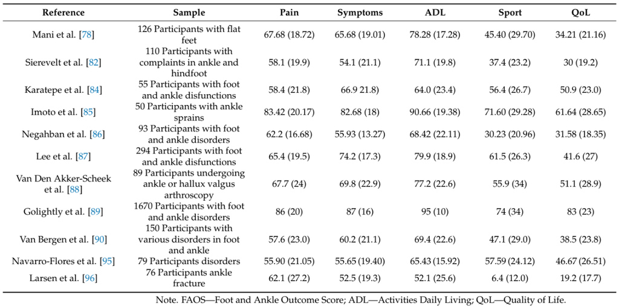

Figure 9: Summary of FAOS subscales from (Alexandre et al. 2024)

However, the present results demonstrate clearly that pathologies restricted to the forefeet return scores that are systematically higher than other regions and those with multiple regions affected (which may include the forefoot). Two key takeaway from the present analysis is firstly, that the FAOS for forefoot conditions may suffer from ceiling effects, particularly for relatively minor conditions. Secondly, future efforts of this kind should consider i) collating forefoot presentations into their own separate cohort and ii) utilising a forefoot-specific PROM, that is appropriate for a broad range of conditions, but is contextually valid to patients presenting for surgical review for forefoot pathology and iii) investigation further the patterns of ceiling effects in these subscales.

Where arthritis is present in a clinical presentation of a foot-ankle condition, either as the primary driver of symptoms or concomitant with other pathologies, a patient can be expected to score lower on all FAOS subscales except for Activities of Daily Living. While this effect is not in itself overly surprising, the variation in the magnitude of differences from one subscale to the next is somewhat contrary to popular belief. The variation in differences between those with ankle arthritis, ankle conditions without arthritis present, and patients presenting with multiple pathologies of which arthritis is one of them could be attributed to a number of mechanisms. The first is that patients are unable to differentiate sufficiently for different patterns of pain or function deficits from one condition to the next. The second is that the subscales themselves are not sufficiently discerning to describe patterns of symptoms.

## 5.4 RECORD [21] Generalisability

The present study represents a relatively large-scale analysis of FAOS subscales across a broad range of conditions electing to undergo surgical review during and some years after the COVID pandemic, within a relatively narrow geographical area of a major metropolitan centre in Australia, with a majority non-urgent case load combined with some trauma cases.

With the COVID pandemic and the mitigation strategies employed exceptional with respect to their effect on healthcare (shift to telemedicine, restriction on theatre access), there is likely to be a finite limit on the generalisability of the present results, particularly as time goes on and case-mix evolves.

Nevertheless, the present study represents one of the largest analyses of foot-ankle pathology in a surgical setting, and describes differences in self-reported pain, function and quality of life with a general scale that has been widely used internationally. Further work should attempt to replicate these findings over a wider collaborative network that includes variation in geography and patient case-mix.

# 6 Other information

## 6.1 RECORD [22] Funding

The SOFARI registry was self-funded by the participating surgeons. The analysis for this study was also self-funded by the participating surgeons.

## 6.2 RECORD [23] Accessibility of protocol, raw data, and programming code

Programming code is incorporated into this document.

Study data may be accessed for reasonable research activities by contacting the corresponding author.

## References

Aden-Buie, Garrick. 2023. “Epoxy: String Interpolation for Documents, Reports and Apps.” https://CRAN.R-project.org/package=epoxy.

Alexandre, Élio, Diogo Monteiro, Ricardo SottoMayor, Miguel Jacinto, Fernanda M. Silva, Luis Cid, and Pedro Duarte-Mendes. 2024. “Assessing Functional Ankle Instability in Sport: A Critical Review and Bibliometric Analysis.” *Healthcare* 12 (17): 1733. https://doi.org/10.3390/healthcare12171733.

Allaire, JJ, and Christophe Dervieux. 2024. “Quarto: R Interface to ’Quarto’ Markdown Publishing System.” https://CRAN.R-project.org/package=quarto.

Arel-Bundock, Vincent. 2024. “Marginaleffects: Predictions, Comparisons, Slopes, Marginal Means, and Hypothesis Tests.” https://CRAN.R-project.org/package=marginaleffects.

Barbone, Jordan Mark, and Jan Marvin Garbuszus. 2024. “Openxlsx2: Read, Write and Edit ’Xlsx’ Files.” https://janmarvin.github.io/openxlsx2/.

Benchimol, Eric I., Liam Smeeth, Astrid Guttmann, Katie Harron, David Moher, Irene Petersen, Henrik T. Sørensen, Erik von Elm, and Sinéad M. Langan. 2015. “The REporting of Studies Conducted Using Observational Routinely-Collected Health Data (RECORD) Statement.” *PLOS Medicine* 12 (10): e1001885. https://doi.org/10.1371/journal.pmed.1001885.

Bengtsson, Henrik. 2021. “A Unifying Framework for Parallel and Distributed Processing in r Using Futures” 13. https://doi.org/10.32614/RJ-2021-048.

———. 2024. “Progressr: An Inclusive, Unifying API for Progress Updates.” https://CRAN.R-project.org/package=progressr.

Bryan, Jennifer, Craig Citro, and Hadley Wickham. 2023. “Gargle: Utilities for Working with Google APIs.” https://CRAN.R-project.org/package=gargle.

Buuren, Stef van, and Karin Groothuis-Oudshoorn. 2011. “Mice: Multivariate Imputation by Chained Equations in r” 45: 1–67. https://doi.org/10.18637/jss.v045.i03.

Carroll, Orlagh U., Tim P. Morris, and Ruth H. Keogh. 2020. “How Are Missing Data in Covariates Handled in Observational Time-to-Event Studies in Oncology? A Systematic Review.” *BMC Medical Research Methodology* 20 (1). https://doi.org/10.1186/s12874-020-01018-7.

Cheng, Sheung-Tak, Phoon Ping Chen, Yu Fat Chow, Joanne W. Y. Chung, Alexander C. B. Law, Jenny S. W. Lee, Edward M. F. Leung, and Cindy W. C. Tam. 2019. “The Pain Catastrophizing Scaleshort Form: Psychometric Properties and Threshold for Identifying High-Risk Individuals.” *International Psychogeriatrics* 31 (11): 1665–74. https://doi.org/10.1017/s1041610219000024.

Davies, G. Matt, and Alan Gray. 2015. “Don’t Let Spurious Accusations of Pseudoreplication Limit Our Ability to Learn from Natural Experiments (and Other Messy Kinds of Ecological Monitoring).” *Ecology and Evolution* 5 (22): 5295–5304. https://doi.org/10.1002/ece3.1782.

Dayim, Alim. 2023. “Consort: Create Consort Diagram.” https://CRAN.R-project.org/package=consort.

Desai, Sameer, Alexander C. Peterson, Kevin Wing, Alastair Younger, Trafford Crump, Guiping Liu, Andrea Veljkovic, Murray Penner, and Jason M. Sutherland. 2019. “Minimally Important Difference in the Foot and Ankle Outcome Score Among Patients Undergoing Hallux Valgus Surgery.” *Foot & Ankle International* 40 (6): 694–701. https://doi.org/10.1177/1071100719831392.

Fatima, Manaal, Nalan Ektas, Corey Scholes, Michael Symes, and Andrew Wines. 2022. “The Effect of Osteotomy Technique (Flat-Cut Vs Wedge-Cut Weil) on Pain Relief and Complication Incidence Following Surgical Treatment for Metatarsalgia in a Private Metropolitan Clinic: Protocol for a Randomised Controlled Trial.” *Trials* 23 (1). https://doi.org/10.1186/s13063-022-06591-4.

Firke, Sam. 2024. “Janitor: Simple Tools for Examining and Cleaning Dirty Data.” https://CRAN.R-project.org/package=janitor.

Iannone, Richard, Joe Cheng, Barret Schloerke, Ellis Hughes, Alexandra Lauer, and JooYoung Seo. 2024. “Gt: Easily Create Presentation-Ready Display Tables.” https://CRAN.R-project.org/package=gt.

Lazic, Stanley E. 2010. “The Problem of Pseudoreplication in Neuroscientific Studies: Is It Affecting Your Analysis?” *BMC Neuroscience* 11 (1). https://doi.org/10.1186/1471-2202-11-5.

Nguyen, Van Thu, Mishelle Engleton, Mauricia Davison, Philippe Ravaud, Raphael Porcher, and Isabelle Boutron. 2021. “Risk of Bias in Observational Studies Using Routinely Collected Data of Comparative Effectiveness Research: A Meta-Research Study.” *BMC Medicine* 19 (1). https://doi.org/10.1186/s12916-021-02151-w.

Palmen, Leonieke N., Maartje Belt, Miranda L. van Hooff, and Angelique G. H. Witteveen. 2025. “Outcome Measures After Foot and Ankle Surgery: A Systematic Review.” *Foot and Ankle Surgery*, February. https://doi.org/10.1016/j.fas.2025.02.005.

Pedersen, Thomas Lin. 2023. “Patchwork: The Composer of Plots.” https://CRAN.R-project.org/package=patchwork.

R Core Team. 2023. “R: A Language and Environment for Statistical Computing.” https://www.R-project.org/.

Robin, Xavier, Natacha Turck, Alexandre Hainard, Natalia Tiberti, Frédérique Lisacek, Jean-Charles Sanchez, and Markus Müller. 2011. “pROC: An Open-Source Package for r and s+ to Analyze and Compare ROC Curves” 12: 77.

Roos, Ewa M., Sveinbjörn Brandsson, and Jon Karlsson. 2001. “Validation of the Foot and Ankle Outcome Score for Ankle Ligament Reconstruction.” *Foot & Ankle International* 22 (10): 788–94. https://doi.org/10.1177/107110070102201004.

Sangha, Oliver, Gerold Stucki, Matthew H. Liang, Anne H. Fossel, and Jeffrey N. Katz. 2003. “The Self-Administered Comorbidity Questionnaire: A New Method to Assess Comorbidity for Clinical and Health Services Research.” *Arthritis Care & Research* 49 (2): 156–63. https://doi.org/10.1002/art.10993.

Scholes, Corey, Kevin Eng, Meredith Harrison-Brown, Milad Ebrahimi, Graeme Brown, Stephen Gill, and Richard Page. 2023. “Patient Registry of Upper Limb Outcomes (PRULO): A Protocol for an Orthopaedic Clinical Quality Registry to Monitor Treatment Outcomes.” *Journal of Surgical Protocols and Research Methodologies* 2023 (4). https://doi.org/10.1093/jsprm/snad014.

Selim, Alfredo J., William Rogers, John A. Fleishman, Shirley X. Qian, Benjamin G. Fincke, James A. Rothendler, and Lewis E. Kazis. 2008. “Updated U.S. Population Standard for the Veterans RAND 12-Item Health Survey (VR-12).” *Quality of Life Research* 18 (1): 43–52. https://doi.org/10.1007/s11136-008-9418-2.

Sierevelt, I. N., I. C. M. van Eekeren, D. Haverkamp, M. L. Reilingh, C. B. Terwee, and G. M. M. J. Kerkhoffs. 2015. “Evaluation of the Dutch Version of the Foot and Ankle Outcome Score (FAOS): Responsiveness and Minimally Important Change.” *Knee Surgery, Sports Traumatology, Arthroscopy* 24 (4): 1339–47. https://doi.org/10.1007/s00167-015-3941-9.

Sierevelt, Inger N., Paulien M. van Kampen, Caroline B. Terwee, Peter A. Nolte, Gino M. M. J. Kerkhoffs, and Daniel Haverkamp. 2024. “The Minimal Important Change Is Not a Universal Fixed Value Across Diagnoses When Using the FAOS and FAAM in Patients Undergoing Elective Foot and Ankle Surgery.” *Knee Surgery, Sports Traumatology, Arthroscopy* 32 (9): 2406–19. https://doi.org/10.1002/ksa.12308.

Silge, Julia, and David Robinson. 2016. “Tidytext: Text Mining and Analysis Using Tidy Data Principles in r” 1. https://doi.org/10.21105/joss.00037.

Sjoberg, Daniel D., Karissa Whiting, Michael Curry, Jessica A. Lavery, and Joseph Larmarange. 2021. “Reproducible Summary Tables with the Gtsummary Package” 13: 570–80. https://doi.org/10.32614/RJ-2021-053.

Tapaninaho, Krista, Mikko M. Uimonen, Antti J. Saarinen, and Jussi P. Repo. 2022. “Minimal Important Change for Foot and Ankle Outcome Score (FAOS).” *Foot and Ankle Surgery* 28 (1): 44–48. https://doi.org/10.1016/j.fas.2021.01.009.

Tenan, Matthew S., Janet E. Simon, Richard J. Robins, Ian Lee, Andrew J. Sheean, and Jonathan F. Dickens. 2020. “Anchored Minimal Clinically Important Difference Metrics: Considerations for Bias and Regression to the Mean.” *Journal of Athletic Training* 56 (9): 1042–49. https://doi.org/10.4085/1062-6050-0368.20.

Tennant, Peter W G, Eleanor J Murray, Kellyn F Arnold, Laurie Berrie, Matthew P Fox, Sarah C Gadd, Wendy J Harrison, et al. 2020. “Use of Directed Acyclic Graphs (DAGs) to Identify Confounders in Applied Health Research: Review and Recommendations.” *International Journal of Epidemiology* 50 (2): 620–32. https://doi.org/10.1093/ije/dyaa213.

Tierney, Nicholas, and Dianne Cook. 2023. “Expanding Tidy Data Principles to Facilitate Missing Data Exploration, Visualization and Assessment of Imputations” 105. https://doi.org/10.18637/jss.v105.i07.

Vaughan, Davis, and Matt Dancho. 2022. “Furrr: Apply Mapping Functions in Parallel Using Futures.” https://CRAN.R-project.org/package=furrr.

Wickham, Hadley, Mara Averick, Jennifer Bryan, Winston Chang, Lucy D’Agostino McGowan, Romain François, Garrett Grolemund, et al. 2019. “Welcome to the Tidyverse” 4: 1686. https://doi.org/10.21105/joss.01686.

Wickham, Hadley, Jim Hester, Winston Chang, Kirill Müller, and Daniel Cook. 2021. “Memoise: ’Memoisation’ of Functions.” https://CRAN.R-project.org/package=memoise.